# Tema 11 - Teoría de la aproximación.

## Teoría de la aproximación

## Introducción

En este capítulo vamos a estudiar técnicas para **aproximar** una función cualquiera por una **combinación lineal de funciones simples o conocidas** como pueden ser las **funciones polinómicas** o las **funciones trigonométricas**.

La **Teoría de la aproximación** intenta resolver dos problemas:

- cuando la función a aproximar \(f\) viene dada de forma **explícita**, queremos hallar como hemos señalado antes otra función \(\hat{f}\), escrita en términos de funciones **simples** o más **conocidas**, de tal forma que \(\hat{f}\) esté lo más **próxima** a \(f\).
- cuando nos dan unos valores **discretos** \((x_k,y_k)\), \(k=0,\ldots,m\), queremos hallar la “mejor” función \(\hat{f}\) escrita también en términos de funciones **simples** o más **conocidas**, que aproxime la **nube de puntos** anterior.

## Introducción

En los problemas anteriores, no hemos concretado un punto importante: ¿qué queremos decir cuando decimos que \(\hat{f}\) esté lo más **próxima** a \(f\)?

Por ejemplo, en el tema dedicado a **interpolación** del curso **Métodos numéricos con Python. Cálculo Numérico** estudiamos cómo hallar el **polinomio de interpolación** de grado \(m-1\), \(p_{m-1}(x)\), dada una **nube de puntos** \((x_k,y_k),\ k=1,\ldots,m\), es decir, hallar un polinomio de grado menor o igual que \(m-1\) tal que \(p_{m-1}(x_k)=y_k\), \(k=1,\ldots,m\).

Cuando los puntos anteriores \((x_k,y_k)\) forman parte de la gráfica de una función \(f\), \(f(x_k)=y_k\), hallar el **polinomio de interpolación** sería una **manera muy particular** de aproximar dicha función \(f\).

Por tanto, en este caso, decir que \(\hat{f}=p_{m-1}\) esté cerca de \(f\) significa que la función interpoladora \(\hat{f}=p_{m-1}\) pase por los puntos de la nube: \(\hat{f}(x_k)=f(x_k)\).

Veremos otras formas de **aproximar** aparte de **imponer** que la **función de aproximación** \(\hat{f}\) pase por \(m\) puntos de la **gráfica de la función a aproximar** \(f\).

## Aproximación discreta por mínimos cuadrados

## Introducción

La **aproximación por mínimos cuadrados** consiste en, dado un conjunto de \(m\) puntos \((x_k,y_k)\), \(k=1,\ldots,m\), donde los \(x_k\) son diferentes \(2\) a \(2\), hallar una función \(\hat{f}(x)\) tal que la **función error** definida por: \[ E(\hat{f})=\sum_{k=1}^m (y_k-\hat{f}(x_k))^2, \] sea **mínima**.

La razón de que se llame **aproximación por mínimos cuadrados** es la expresión de la **función error** que consiste en la **suma de los cuadrados de los errores cometidos** en cada ordenada de cada punto \((x_k,y_k): (y_k-\hat{f}(x_k))^2\).

El siguiente paso es escoger el **espacio de funciones** donde elegiremos la función aproximación \(\hat{f}\) de la que hallaremos el mínimo.

## Aproximación lineal Mínimos cuadrados

Cuando el **espacio de funciones** considerado es el conjunto de funciones lineales, es decir, funciones del tipo \[ \hat{f}(x)=a_0+a_1 x, \] donde \(a_0\) y \(a_1\) son **coeficientes libres** que se tienen que calcular a partir de la nube de puntos \((x_k,y_k)\), \(k=1,\ldots,m\), la **aproximación por mínimos cuadrados** se denomina **aproximación lineal por mínimos cuadrados**.

## Aproximación lineal Mínimos cuadrados

Si la nube de puntos tiene una tendencia lineal como la del gráfico siguiente, hallar la **aproximación lineal por mínimos cuadrados** es hallar la mejor **recta** (en azul) tal que la **función error** antes definida es mínima, es decir, hallamos los coeficientes \(a_0\) y \(a_1\) tal que la suma de los errores (en rojo) al cuadrado entre las ordenadas \(y_k\) y los valores dados por la recta \(a_0+a_1 x_k\), \((y_k-a_0-a_1 x_k)^2\) es mínima.

## Aproximación lineal Mínimos cuadrados

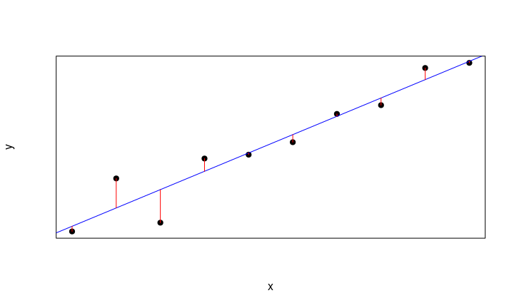

## Cálculo de los coeficientes \(a_0\) y \(a_1\)

Para hallar los coeficientes \(a_0\) y \(a_1\), tenemos que **minimizar** la **función error** que depende de dichos coeficientes: \[ E(a_0,a_1)=\sum_{k=1}^m (y_k-\hat{f}(x_k))^2 = \sum_{k=1}^m (y_k-a_0-a_1 x_k)^2. \] Para hallar los extremos de la **función error** \(E(a_0,a_1)\) de dos variables, tenemos que resolver el sistema siguiente: \[ \frac{\partial E(a_0,a_1)}{\partial a_0}=0,\quad \frac{\partial E(a_0,a_1)}{\partial a_1}=0. \]

## Cálculo de los coeficientes \(a_0\) y \(a_1\)

Es decir: \[ \begin{align*} \frac{\partial E(a_0,a_1)}{\partial a_0} = & \frac{\partial}{\partial a_0}\sum_{k=1}^m (y_k-a_0-a_1 x_k)^2=-2\sum_{k=1}^m (y_k-a_0-a_1 x_k)\\ = & -2\left(\sum_{k=1}^m y_k-ma_0-a_1\sum_{k=1}^m x_k\right)=0,\\ \frac{\partial E(a_0,a_1)}{\partial a_1} = & \frac{\partial}{\partial a_1}\sum_{k=1}^m (y_k-a_0-a_1 x_k)^2=-2\sum_{k=1}^m (y_k-a_0-a_1 x_k)x_k\\ = & -2\left(\sum_{k=1}^m x_k y_k-a_0\sum_{k=1}^m x_k -a_1\sum_{k=1}^m x_k^2\right)=0. \end{align*} \]

## Cálculo de los coeficientes \(a_0\) y \(a_1\)

Simplificando el sistema anterior, tenemos que los coeficientes \(a_0\) y \(a_1\) deben verificar el sistema de ecuaciones siguientes llamado **sistema de ecuaciones normales**: \[ \begin{align*} m a_0 + \left(\sum_{k=1}^m x_k\right) a_1 = & \sum_{k=1}^m y_k,\\ \left(\sum_{k=1}^m x_k\right) a_0+\left(\sum_{k=1}^m x_k^2\right) a_1 = & \sum_{k=1}^m x_k y_k. \end{align*} \]

## Cálculo de los coeficientes \(a_0\) y \(a_1\)

Si llamamos \[ \Sigma_x =\sum_{k=1}^m x_k,\ \Sigma_y =\sum_{k=1}^m y_k,\ \Sigma_{x2} =\sum_{k=1}^m x_k^2,\ \Sigma_{xy} =\sum_{k=1}^m x_k y_k, \] el sistema anterior puede escribirse como: \[ \begin{align*} m a_0 + \Sigma_x a_1 = & \Sigma_y,\\ \Sigma_x a_0+\Sigma_{x2} a_1 = & \Sigma_{xy}, \end{align*} \] cuya solución puede obtenerse por el **método de Cramer**: \[ a_0 = \frac{\left|\begin{matrix}\Sigma_y & \Sigma_x\\ \Sigma_{xy}& \Sigma_{x2}\end{matrix}\right|}{\left|\begin{matrix}m & \Sigma_x\\ \Sigma_{x}& \Sigma_{x2}\end{matrix}\right|}=\frac{\Sigma_y\Sigma_{x2}-\Sigma_x\Sigma_{xy}}{m\Sigma_{x2}-\Sigma_x^2},\ a_1 = \frac{\left|\begin{matrix}m & \Sigma_y\\ \Sigma_{x}& \Sigma_{xy}\end{matrix}\right|}{\left|\begin{matrix}m & \Sigma_x\\ \Sigma_{x}& \Sigma_{x2}\end{matrix}\right|}=\frac{m\Sigma_{xy}-\Sigma_x\Sigma_{y}}{m\Sigma_{x2}-\Sigma_x^2}. \]

## Cálculo de los coeficientes \(a_0\) y \(a_1\)

Usando las siguientes deficiones de **estadística descriptiva**: \[ \overline{x}=\frac{\Sigma_x}{m},\ \overline{y}=\frac{\Sigma_y}{m},\ s_{x}^2 =\frac{\Sigma_{x2}}{m}-\overline{x}^2,\ s_{xy}=\frac{\Sigma_{xy}}{m}-\overline{x}\overline{y}, \] las expresiones para \(a_0\) y \(a_1\) pueden escribirse como: \[ \begin{align*} a_1 =& \frac{m\Sigma_{xy}-\Sigma_x\Sigma_{y}}{m\Sigma_{x2}-\Sigma_x^2}=\frac{\frac{1}{m^2}\left(m\Sigma_{xy}-\Sigma_x\Sigma_{y}\right)}{\frac{1}{m^2}\left(m\Sigma_{x2}-\Sigma_x^2\right)}=\frac{\frac{\Sigma_{xy}}{m}-\overline{x}\overline{y}}{\frac{\Sigma_{x2}}{m}-\overline{x}^2}=\frac{s_{xy}}{s_x^2},\\ a_0 = & \frac{\Sigma_y\Sigma_{x2}-\Sigma_x\Sigma_{xy}}{m\Sigma_{x2}-\Sigma_x^2}=\frac{\frac{1}{m^2}\left(\Sigma_y\Sigma_{x2}-\Sigma_x\Sigma_{xy}\right)}{\frac{1}{m^2}\left(m\Sigma_{x2}-\Sigma_x^2\right)}=\frac{\overline{y}\frac{\Sigma_{x2}}{m}-\overline{x}\frac{\Sigma_{xy}}{m}}{s_x^2}\\ =& \frac{\overline{y}\left(\frac{\Sigma_{x2}}{m}-\overline{x}^2+\overline{x}^2\right)-\overline{x}\frac{\Sigma_{xy}}{m}}{s_x^2}=\frac{\overline{y}\left(s_x^2+\overline{x}^2\right)-\overline{x}\frac{\Sigma_{xy}}{m}}{s_x^2}\\ = & \overline{y}+\overline{x}\left(\frac{\overline{x}\overline{y}-\frac{\Sigma_{xy}}{m}}{s_x^2}\right)=\overline{y}-a_1\overline{x}. \end{align*} \]

## Cálculo de los coeficientes \(a_0\) y \(a_1\)

Para calcular los coeficientes \(a_0\) y \(a_1\), hemos de realizar los pasos siguientes:

- calculamos \(\Sigma_x\), \(\Sigma_y\), \(\Sigma_{x2}\) y \(\Sigma_{xy}\),
- calculamos \(\overline{x},\overline{y},s_x^2\) y \(s_{xy}\) a partir de los valores anteriores,
- calculamos \(a_1=\frac{s_{xy}}{s_x^2}\) y \(a_0=\overline{y}-a_1\overline{x}\).

Observación.

Vemos que la recta por **aproximación lineal por mínimos cuadrados** pasa por el **punto medio de la nube de puntos** \((\overline{x},\overline{y})\) ya que como \(a_0=\overline{y}-a_1\overline{x}\) tenemos que \(a_0+a_1\overline{x}=\overline{y}\).

## Cálculo de los coeficientes \(a_0\) y \(a_1\)

Observación.

Resolviendo las **ecuaciones normales**, sólo hemos comprobado que los valores \(a_0\) y \(a_1\) anteriores son un **extremo** de la **función error**. Deberíamos comprobar que los valores hallados son un mínimo.

Para ver que un valor candidato a extremo \((a_0,a_1)\) de una función de dos variables \(E(a_0,a_1)\) corresponde a un mínimo, hemos de ver que la **matriz Hesiana** evaluada en \((a_0,a_1)\) es **definida positiva** o que sus **valores propios** son **positivos**.

La matriz Hesiana es la siguiente: \[ H(a_0,a_1)=\begin{bmatrix}\frac{\partial^2 E}{\partial a_0^2} &\frac{\partial^2 E}{\partial a_0\partial a_1}\\ \frac{\partial^2 E}{\partial a_0\partial a_1}& \frac{\partial^2 E}{\partial a_1^2}\end{bmatrix} =\begin{bmatrix}2m&2\sum\limits_{k=1}^m x_k \\ 2\sum\limits_{k=1}^m x_k & 2\sum\limits_{k=1}^m x_k^2\end{bmatrix}. \]

## Cálculo de los coeficientes \(a_0\) y \(a_1\)

Observación (continuación).

Antes de ver que la matriz anterior corresponde a un mínimo, necesitamos el lema siguiente:

Lema.

Dado un conjunto de datos \(x_1,\ldots,x_m\), donde hay como mínimo dos diferentes, su **varianza poblacional** \(s_x^2 = \frac{\sum\limits_{k=1}^m x_k^2}{m}-\overline{x}^2\) es estrictamente positiva, \(s_x^2> 0\).

## Demostración del lema

\[ s_x^2 = \frac{\sum\limits_{k=1}^m x_k^2}{m}-\overline{x}^2 =\frac{\sum\limits_{k=1}^m (x_k-\overline{x})^2}{m}> 0. \] La última igualdad se puede provar de forma sencilla: \[ \begin{align*} \frac{\sum\limits_{k=1}^m (x_k-\overline{x})^2}{m} = & \frac{\sum\limits_{k=1}^m (x_k^2-2\overline{x}x_k+\overline{x}^2)}{m}=\frac{\sum\limits_{k=1}^m x_k^2-2\overline{x}\sum\limits_{k=1}^m x_k+m\overline{x}^2)}{m}\\ = & \frac{\sum\limits_{k=1}^m x_k^2-2\overline{x}m\overline{x}+m\overline{x}^2}{m}= \frac{\sum\limits_{k=1}^m x_k^2-2m\overline{x}^2+m\overline{x}^2}{m}=\frac{\sum\limits_{k=1}^m x_k^2-m\overline{x}^2}{m}\\ = & \frac{\sum\limits_{k=1}^m x_k^2}{m}-\overline{x}^2 \end{align*} \]

## Cálculo de los coeficientes \(a_0\) y \(a_1\)

Observación (continuación).

Para ver que la matriz \(H(a_0,a_1)\) es **definida positiva** podemos usar la **regla de Sylvester**, que dice que si los determinantes de orden \(1\) y \(2\) son **positivos**, la matriz \(H(a_0,a_1)\) es **definida positiva**: \[ \begin{align*} H(a_0,a_1)_1 =& 2m>0,\\ H(a_0,a_1)_2 = & 4m\sum_{k=1}^m x_k^2-4 \left(\sum_{k=1}^m x_k\right)^2 =\frac{4}{m^2}\left(\frac{\sum\limits_{k=1}^m x_k^2}{m}-\overline{x}^2\right)=\frac{4}{m^2}\cdot s_x^2 >0. \end{align*} \] En la última igualdad hemos aplicado el lema anterior.

Por tanto, concluimos que el valor \((a_0,a_1)\) hallado corresponde a un **mínimo** de la función **error** \(E(a_0,a_1)\).

## Mínimos cuadrados lineal. Pseudocódigo

- `INPUT número de puntos de la nube` \(m\), `puntos de la nube` \((x_k,y_k)\), \(k=1,\ldots,m\)
- `Set` \(Sigmax=0\).
- `Set` \(Sigmay=0\).
- `Set` \(Sigmax2=0\).
- `Set` \(Sigmaxy=0\).
- `For k=1,...,m`
  - `Set` \(Sigmax=Sigmax+x_k\).
  - `Set` \(Sigmay=Sigmay+y_k\).
  - `Set` \(Sigmax2=Sigmax2+x_k^2\).
  - `Set` \(Sigmaxy=Sigmaxy+x_k\cdot y_k\).

## Mínimos cuadrados lineal. Pseudocódigo

- `Set` \(\overline{x}=\frac{Sigmax}{m}\).
- `Set` \(\overline{y}=\frac{Sigmay}{m}\).
- `Set` \(s_x^2 = \frac{Sigmax2}{m}-\overline{x}^2\).
- `Set` \(s_{xy}= \frac{Sigmaxy}{m}-\overline{x}\cdot \overline{y}\).
- `Set` \(a_1=\frac{s_{xy}}{s_x^2}\).
- `Set` \(a_0=\overline{y}-a_1\cdot\overline{x}\).
- `Print` \(a_0,a_1\).

## Ejemplo

Consideremos la nube de puntos siguientes:

| \(x\) | \(y\) |
| --- | --- |
| \(1\) | \(1.6620781\) |
| \(2\) | \(7.5824881\) |
| \(3\) | \(2.6419837\) |
| \(4\) | \(9.8076052\) |
| \(5\) | \(10.2366814\) |
| \(6\) | \(11.629404\) |
| \(7\) | \(14.7915203\) |

## Ejemplo (continuación)

| \(x\) | \(y\) |
| --- | --- |
| \(8\) | \(15.7676398\) |
| \(9\) | \(19.9221514\) |
| \(10\) | \(20.4909214\) |

- En primer lugar calculamos: \[ \begin{align*} \Sigma_x = & 1+2+3+4+5+6+7+8+9+10=55,\\ \Sigma_y = & 1.6620781+7.5824881+2.6419837+9.8076052+10.2366814+11.629404+14.7915203\\ & \quad +15.7676398+19.9221514+20.4909214=114.5324735,\\ \Sigma_{x2} = & 1^2+2^2+3^2+4^2+5^2+6^2+7^2+8^2+9^2+10^2=385,\\ \Sigma_{xy} = & 1\cdot 1.6620781+2\cdot 7.5824881+3\cdot 2.6419837+4\cdot 9.8076052+5\cdot 10.2366814+6\cdot 11.629404\\ & \quad +7\cdot 14.7915203 +8\cdot 15.7676398+9\cdot 19.9221514+10\cdot 20.4909214=798.8335946. \end{align*} \]

## Ejemplo (continuación)

- A continuación calculamos: \[ \begin{align*} \overline{x}= & \frac{\Sigma_x}{m}=\frac{55}{10}=5.5,\\ \overline{y}= & \frac{\Sigma_y}{m}=\frac{114.5324735}{10}=11.4532473,\\ s_x^2 = & \frac{\Sigma_{x2}}{m}-\overline{x}^2 =\frac{385}{10}-5.5^2 = 8.25,\\ s_{xy} = & \frac{\Sigma_{xy}}{m}-\overline{x}\cdot\overline{y}=\frac{798.8335946}{10}-5.5\cdot11.4532473= 16.8904991. \end{align*} \]
- Por último, calculamos los coeficientes \(a_0\) y \(a_1\): \[ \begin{align*} a_1 = & \frac{s_{xy}}{s_x^2}=\frac{16.8904991}{8.25}=2.0473332,\\ a_0 = & \overline{y}-a_1\cdot\overline{x}=11.4532473-2.0473332\cdot 5.5=0.1929146. \end{align*} \]

## Ejemplo (continuación)

La gráfica siguiente muestra los puntos junto con la recta de aproximación lineal:

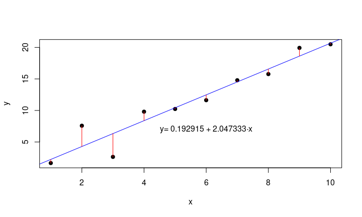

## Ejemplo (continuación)

El error mínimo cometido al aproximar la nube de puntos por una recta vale: \[ \begin{align*} E(a_0,a_1) = & E(0.1929146,2.0473332)=\sum_{k=1}^{10} (y_k-0.1929146-2.0473332\cdot x_k)^2\\ = & (1.6620781-0.1929146-2.0473332\cdot 1)^2+(7.5824881-0.1929146-2.0473332\cdot 2)^2\\ = & (2.6419837-0.1929146-2.0473332\cdot 3)^2+(9.8076052-0.1929146-2.0473332\cdot 4)^2\\ = & (10.2366814-0.1929146-2.0473332\cdot 5)^2+(11.629404-0.1929146-2.0473332\cdot 6)^2\\ = & (14.7915203-0.1929146-2.0473332\cdot 7)^2+(15.7676398-0.1929146-2.0473332\cdot 8)^2\\ = & (19.9221514-0.1929146-2.0473332\cdot 9)^2+(20.4909214-0.1929146-2.0473332\cdot 10)^2 \\ = & 30.06248. \end{align*} \]

Podemos comprobar también que la recta \(y=a_0+a_1x=0.1929146+2.0473332\cdot x\) pasa por el punto \((\overline{x},\overline{y})=(5.5,11.4532473)\): \[ \overline{y}=a_0+a_1\overline{x},\quad 11.4532473=0.1929146+2.0473332\cdot 5.5. \]

## Aproximación polinomial por mínimos cuadrados

Vamos a generalizar el estudio anterior.

En lugar de considerar como **espacio de funciones** el conjunto de funciones lineales, vamos a considerar el conjunto de **polinomios de grado máximo \(n\)**: \[ P_n(x)=a_n x^n+a_{n-1}x^{n-1}+\cdots +a_1 x+a_0, \] es decir, el problema que nos planteamos es el siguiente:

## Aproximación polinomial por mínimos cuadrados

Problema de aproximación polinomial por mínimos cuadrados

Consideramos una nube de puntos \((x_k,y_k)\), \(k=1,\ldots,m\), donde los \(x_k\) son diferentes \(2\) a \(2\). Queremos hallar el **polinomio \(P_n(x)\)** de grado menor o igual que \(n\), con \(n< m-1\), tal que la **función error** siguiente sea mínima: \[ \begin{align*} E(a_0,a_1,\ldots,a_n)= & \sum_{k=1}^m (y_k-\hat{f}(x_k))^2 \\ =& \sum_{k=1}^m (y_k-(a_n x_k^n+a_{n-1}x_k^{n-1}+\cdots +a_1x_k+a_0))^2. \end{align*} \]

## Aproximación polinomial por mínimos cuadrados

Observación.

La condición \(n<m-1\) se impone ya que sabemos que si \(n=m-1\) existe un polinomio denominado **polinomio interpolador** que cumple \(P_n(x_k)=y_k\).

Para este polinomio, tendremos que \(E(a_0,a_1,\ldots,a_n)=0\) ya que los sumandos que hay en el **sumatorio** de la **función error** son todos nulos.

En este caso, el problema quedaría resuelto usando dicho **polinomio interpolador**.

En resumen, intentamos solucionar el problema de **aproximar** de la mejor manera posible la **nube de puntos** por un polinomio cuyo grado no supere \(m-1\), siendo \(m\) el número de puntos de la nube.

## Cálculo de los coeficientes \(a_k\), \(i=0,\ldots,n\)

La función **error** es una función de \(n+1\) variables: \(a_0,a_1,\ldots,a_n\).

Para hallar el **mínimo** de la misma hemos de resolver el **sistema de ecuaciones** siguiente: \[ \begin{align*} \frac{\partial E}{\partial a_0}(a_0,a_1,\ldots,a_n)= & 0,\\ \frac{\partial E}{\partial a_1}(a_0,a_1,\ldots,a_n)= & 0,\\ &\vdots\\ \frac{\partial E}{\partial a_n}(a_0,a_1,\ldots,a_n)= & 0. \end{align*} \]

## Cálculo de los coeficientes \(a_k\), \(k=0,\ldots,n\)

El valor de \(\displaystyle\frac{\partial E}{\partial a_j}(a_0,a_1,\ldots,a_n)\), \(j=0,\ldots,n\) vale: \[ \begin{align*} & \frac{\partial E}{\partial a_j}(a_0,a_1,\ldots,a_n)=-2\sum_{k=1}^m (y_k-(a_n x_k^n+a_{n-1}x_k^{n-1}+\cdots +a_1 x_k+a_0))\cdot x_k^j\\ & =-2\left(\sum_{k=1}^m y_k\cdot x_k^j-a_n\sum_{k=1}^m x_k^{n+j}-a_{n-1}\sum_{k=1}^m x_k^{n-1+j}-\cdots - a_1\sum_{k=1}^m x_k^{1+j}-a_0\sum_{k=1}^m x_k^{j}\right), \end{align*} \] \(j=0,\ldots,n\).

## Cálculo de los coeficientes \(a_k\), \(k=0,\ldots,n\)

La condición \(\displaystyle\frac{\partial E}{\partial a_j}(a_0,a_1,\ldots,a_n)=0\), \(j=0,\ldots,n\) puede escribirse de la forma siguiente: \[ \begin{align*} & \left(\sum_{k=1}^m x_k^{j}\right)a_0+\left(\sum_{k=1}^m x_k^{1+j}\right)a_1+\cdots +\left(\sum_{k=1}^m x_k^{n-1+j}\right)a_{n-1}+\left(\sum_{k=1}^m x_k^{n+j}\right)a_n\\ & \quad =\sum_{k=1}^m y_k\cdot x_k^j. \end{align*} \]

## Cálculo de los coeficientes \(a_k\), \(k=0,\ldots,n\)

Fijémonos que el **sistema anterior** es lineal con \(n+1\) ecuaciones y \(n+1\) incógnitas \(a_0,a_1,\ldots,a_n\), que puede escribirse de la forma \(\mathbf{A}\mathbf{a}=\mathbf{b}\), donde \[ \begin{align*} \mathbf{A}= & (a_{ij})_{i,j=1,\ldots,n+1}=\left(\sum_{k=1}^m x_k^{i+j-2}\right)_{i,j=1,\ldots,n+1},\ \mathbf{a}=\begin{bmatrix}a_0\\ a_1\\\vdots\\ a_n\end{bmatrix},\\ \mathbf{b}= & \left(\sum_{k=1}^m y_k\cdot x_k^{i-1}\right)_{i=1,\ldots,n+1}. \end{align*} \] Para resolverlo, puede usarse un método directo como el **método de Gauss con pivotaje** o la **descomposición \(LU\)** (ver el curso **Métodos numéricos con Python. Álgebra lineal numérica**.)

## Existencia de solución

Proposición.

El sistema anterior \(\mathbf{A}\mathbf{a}=\mathbf{b}\) tiene solución única.

**Demostración**

Hemos de ver que \(\mathrm{det}(\mathbf{A})\neq 0\).

Supongamos que \(\mathrm{det}(\mathbf{A})=0\). En este caso, la matriz \(\mathbf{A}\) tiene el **valor propio** \(0\).

Sea \(\mathbf{v}=(v_1,v_2,\ldots,v_{n+1})\neq\mathbf{0}\) un **vector propio** de **valor propio** \(0\) de la matriz \(\mathbf{A}\): \(\mathbf{A}\mathbf{v}=\mathbf{0}\).

Es decir: \[ \sum_{j=1}^{n+1} a_{ij}v_j=0,\ i=1,\ldots,{n+1},\ \Rightarrow \sum_{j=1}^{n+1} \sum_{k=1}^m x_k^{i+j-2} v_j=0,\ \Rightarrow \sum_{k=1}^{m}x_k^{i-1}\sum_{j=1}^{n+1}x_k^{j-1}v_j, \ i=1,\ldots,n+1. \] A continuación, consideremos el polinomio de grado \(n\) siguiente: \[ P(x)=\sum_{j=1}^{n+1} x^{j-1} v_j =v_1 +v_2 x+\cdots + v_{n+1}x^n. \]

## Demostración de la proposición (continuación)

La igualdad anterior puede escribirse de la forma siguiente en función del polinomio \(P(x)\) como: \[ \sum_{k=1}^m x_k^{i-1} P(x_k)=0,\ i=1,\ldots,n+1. \] La expresión anterior puede escribirse matricialmente de la forma siguiente:

\[ \begin{align*} \begin{bmatrix}x_{1}^0&x_{2}^0&\ldots&x_{m}^0 \\x_{1}&x_{2}&\ldots&x_{m} \\\vdots&\vdots&\ddots&\vdots \\x_{1}^n&x_{2}^n&\ldots&x_{m}^n \\\end{bmatrix}\cdot\begin{bmatrix}P(x_1)\\ P(x_2)\\\vdots\\ P(x_m)\end{bmatrix}= &\begin{bmatrix}0\\ 0\\\vdots \\ 0\end{bmatrix},\Rightarrow \\ \begin{bmatrix}1&1&\ldots&1 \\x_{1}&x_{2}&\ldots&x_{m} \\\vdots&\vdots&\ddots&\vdots \\x_{1}^n&x_{2}^n&\ldots&x_{m}^n \\\end{bmatrix}\cdot\begin{bmatrix}P(x_1)\\ P(x_2)\\\vdots\\ P(x_m)\end{bmatrix}= &\begin{bmatrix}0\\ 0\\\vdots \\ 0\end{bmatrix} \end{align*} \]

## Demostración de la proposición (continuación)

Usando que \(n<m-1\) o \(n+1<m\), veamos que el rango de la matriz anterior \(\begin{bmatrix}1&1&\ldots&1 \\x_{1}&x_{2}&\ldots&x_{m} \\\vdots&\vdots&\ddots&\vdots \\x_{1}^n&x_{2}^n&\ldots&x_{m}^n \\\end{bmatrix}\) vale \(n+1\).

Efectivamente, el determinante del menor de orden \(n+1\) es el denominado **determinante de Vandermonde**, que ya resolvimos en el **Curso completo de Álgebra lineal con R, Python y Octave**. \[ \begin{vmatrix}1&1&\ldots&1&1 \\x_{1}&x_{2}&\ldots&x_{n}&x_{n+1} \\\vdots&\vdots&\ddots&\vdots&\vdots \\x_{1}^n&x_{2}^n&\ldots&x_{n}^n&x_{n+1}^n \\\end{vmatrix} =\prod_{1\leq i<j\leq n+1}(x_j-x_i). \] Como los \(x_k\), \(k=1,\ldots,m\) son distintos dos a dos, el determinante anterior es diferente de cero y el rango de la matriz \(\begin{bmatrix}1&1&\ldots&1 \\x_{1}&x_{2}&\ldots&x_{m} \\\vdots&\vdots&\ddots&\vdots \\x_{1}^n&x_{2}^n&\ldots&x_{m}^n \\\end{bmatrix}\) vale \(n+1\).

## Demostración de la proposición (continuación)

Entonces la solución del sistema homogéneo: \[ \begin{bmatrix}1&1&\ldots&1 \\x_{1}&x_{2}&\ldots&x_{m} \\\vdots&\vdots&\ddots&\vdots \\x_{1}^n&x_{2}^n&\ldots&x_{m}^n \\\end{bmatrix}\cdot\begin{bmatrix}P(x_1)\\ P(x_2)\\\vdots\\ P(x_m)\end{bmatrix}= \begin{bmatrix}0\\ 0\\\vdots \\ 0\end{bmatrix}, \] es única: \(P(x_1)=P(x_2)=\cdots =P(x_m)=0\).

Hemos obtenido un polinomio \(P(x)\) de grado \(n\) que tiene \(m>n+1\) ceros. Sabemos que un polinomio de grado \(n\) sólo puede tener \(n\) ceros distintos como máximo, es decir \(m\leq n<n+1\), lo que contradice la condición \(m>n+1\).

Deducimos por tanto que \(\mathrm{det}(\mathbf{A})\neq 0\), tal como queríamos demostrar.

## Mínimos cuadrados polinomial. Pseudocódigo

- `INPUT número de puntos de la nube` \(m\), `puntos de la nube` \((x_k,y_k)\), \(k=1,\ldots,m\), \(n\) `grado del polinomio aproximador`
- `Set` \(\mathbf{A}=\mathbf{0}\). (`Inicializamos la matriz` \(\mathbf{A}\) `del sistema` \((n+1)\times (n+1)\) `y el vector independiente` \(\mathbf{b}\))
- `Set` \(\mathbf{b}=\mathbf{0}\).
- `For k=1,...,m` (`Calculamos` \(a_{ij}\), `las componentes de la matriz del sistema` \(\mathbf{A}\) `y las componentes del vector` \(\mathbf{b}\))
  - `For i=1,...,n+1`
    - `Set` \(b[i]=b[i]+y_k\cdot x_k^{i-1}\).
    - `For j=1,...,n+1`
      - `Set` \(A[i,j]=A[i,j]+x_k^{i+j-2}\)

## Mínimos cuadrados polinomial. Pseudocódigo

- `Solve` \(\mathbf{A}\mathbf{a}=\mathbf{b}\) (`Resolvemos el sistema para hallar los coeficientes del polinomio de aproximación` \(\mathbf{a}\))
- `Print` \(a_0,a_1,\ldots,a_n\).

## Ejemplo

Vamos a hallar la aproximación cuadrática (\(n=2\)) de la nube de puntos anterior:

| \(x\) | \(y\) |
| --- | --- |
| \(1\) | \(1.6620781\) |
| \(2\) | \(7.5824881\) |
| \(3\) | \(2.6419837\) |
| \(4\) | \(9.8076052\) |
| \(5\) | \(10.2366814\) |
| \(6\) | \(11.629404\) |
| \(7\) | \(14.7915203\) |

## Ejemplo (continuación)

| \(x\) | \(y\) |
| --- | --- |
| \(8\) | \(15.7676398\) |
| \(9\) | \(19.9221514\) |
| \(10\) | \(20.4909214\) |

## Ejemplo (continuación)

La matriz del sistema \(\mathbf{A}\) y el vector independiente \(\mathbf{b}\) para la aproximación cuadrática son los siguientes: \[ \begin{align*} \mathbf{A}= & \begin{bmatrix}m & \sum\limits_{k=1}^m x_k & \sum\limits_{k=1}^m x_k^2 \\ \sum\limits_{k=1}^m x_k & \sum\limits_{k=1}^m x_k^2 & \sum\limits_{k=1}^m x_k^3 \\ \sum\limits_{k=1}^m x_k^2 & \sum\limits_{k=1}^m x_k^3 & \sum\limits_{k=1}^m x_k^4\end{bmatrix}=\begin{bmatrix}10 & 1+2+\cdots +10 & 1^2+2^2+\cdots +10^2\\ 1+2+\cdots +10 & 1^2+2^2+\cdots +10^2 & 1^3+2^3+\cdots +10^3\\ 1^2 +2^2+\cdots +10^2 & 1^3+2^3+\cdots +10^3 & 1^4+2^4+\cdots +10^4 \end{bmatrix}\\ = & \begin{bmatrix}10&55&385 \\55&385&3025 \\385&3025&25333 \\\end{bmatrix},\\ \mathbf{b} = & \begin{bmatrix}\sum\limits_{k=1}^m y_k\\ \sum\limits_{k=1}^m x_k\cdot y_k\\ \sum\limits_{k=1}^m x_k^2\cdot y_k\end{bmatrix}=\begin{bmatrix} 1.6620781+7.5824881+\cdots + 20.4909214 \\ 1\cdot 1.6620781+2\cdot 7.5824881+\cdots +10\cdot 20.4909214\\ 1^2\cdot 1.6620781+2^2\cdot 7.5824881+\cdots +10^2\cdot 20.4909214\end{bmatrix}= \begin{bmatrix}114.532473470475 \\798.833594605984 \\6283.96699294644 \\\end{bmatrix}. \end{align*} \]

## Ejemplo (continuación)

La solución del sistema \(\mathbf{A}\mathbf{a}=\mathbf{b}\) es la siguiente: \[ \mathbf{a}=\begin{bmatrix}0.880909172117338 \\1.70333595525723 \\0.0312724784679324 \\\end{bmatrix}. \]

El polinomio de aproximación de grado \(2\) por mínimos cuadrados es el siguiente: \[ P(x)=0.8809092+1.703336\cdot x+0.0312725\cdot x^2. \] El gráfico siguiente muestra la nube de puntos junto con la aproximación cuadrática (en azul).

## Ejemplo (continuación)

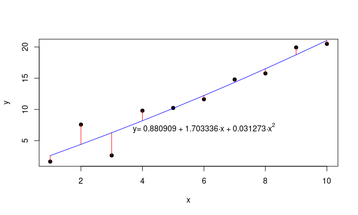

## Ejemplo (continuación)

El error mínimo cometido al aproximar la nube de puntos por el polinomio cuadrático vale: \[ \begin{align*} E(a_0,a_1,a_2) = & E(0.8809092,1.703336,0.0312725)=\sum_{k=1}^{10} (y_k-0.8809092-1.703336\cdot x_k-0.0312725\cdot x_k^2)^2\\ = & (1.6620781-0.8809092-1.703336\cdot 1-1.703336\cdot 1^2)^2 \\ & \quad +(7.5824881-0.8809092-1.703336\cdot 2-1.703336\cdot 2^2)^2 \\ & \quad +(2.6419837-0.8809092-1.703336\cdot 3-1.703336\cdot 3^2)^2\\ & \quad +(9.8076052-0.8809092-1.703336\cdot 4-1.703336\cdot 4^2)^2\\ & \quad +(10.2366814-0.8809092-1.703336\cdot 5-1.703336\cdot 5^2)^2\\ & \quad +(11.629404-0.8809092-1.703336\cdot 6-1.703336\cdot 6^2)^2\\ & \quad +(14.7915203-0.8809092-1.703336\cdot 7-1.703336\cdot 7^2)^2\\ & \quad +(15.7676398-0.8809092-1.703336\cdot 8-1.703336\cdot 8^2)^2\\ & \quad +(19.9221514-0.8809092-1.703336\cdot 9-1.703336\cdot 9^2)^2\\ & \quad +(20.4909214-0.8809092-1.703336\cdot 10-1.703336\cdot 10^2)^2\\= & 29.546113. \end{align*} \] Hemos reducido el error con respecto la aproximación lineal pero no demasiado.

## Transformación logarítmica

En ocasiones, la mejor forma de **aproximar** la nube de puntos no tiene por qué ser **lineal** e incluso **polinómica**.

Imaginemos una situación en que la relación entre los puntos sea **exponencial** con una función de tipo \(y=b\cdot\mathrm{e}^{ax}\) o **potencial** con una función del tipo \(y=b\cdot x^a\), donde las constantes \(a\) y \(b\) se tienen que hallar de forma que minimicen la función **error** \[ E(a,b)=\sum_{k=1}^m \left(y_k-b\mathrm{e}^{a x_k}\right)^2, \] en el caso de relación **exponencial** o, \[ E(a,b)=\sum_{k=1}^m \left(y_k-b\cdot x_k^a\right)^2, \] en el caso de relación **potencial**.

## Relación exponencial

En el caso de relación **exponencial** de la nube de puntos, para hallar las “mejores” \(a\) y \(b\) tenemos que resolver el siguiente sistema de ecuaciones siguiendo el mismo procedimiento del método de **mínimos cuadrados**: \[ \begin{align*} & \frac{\partial E}{\partial a}(a,b)= -2\sum_{k=1}^m \left(y_k-b\mathrm{e}^{ax_k}\right)\cdot b\cdot x_k\cdot\mathrm{e}^{a x_k}=0,\ \stackrel{b\neq 0}{\Rightarrow} \\ & b\sum_{k=1}^m x_k\cdot \mathrm{e}^{2ax_k}=\sum_{k=1}^m x_k\cdot y_k\cdot\mathrm{e}^{ax_k}, \\ & \frac{\partial E}{\partial b}(a,b)= -2\sum_{k=1}^m \left(y_k-b\mathrm{e}^{ax_k}\right)\cdot \mathrm{e}^{a x_k}=0,\ \Rightarrow b\sum_{k=1}^m \mathrm{e}^{2ax_k}=\sum_{k=1}^m y_k\cdot \mathrm{e}^{ax_k}. \end{align*} \] Para hallar los coeficientes \(a\) y \(b\) que minimicen la función **error**, tendremos que resolver el sistema anterior.

Fijémonos que el sistema anterior es una sistema **no lineal**. Su resolución es en general **compleja** y no siempre tenemos asegurada la **solución** del mismo.

## Relación potencial

En el caso de relación **potencial** de la nube de puntos, para hallar las “mejores” \(a\) y \(b\) tenemos que resolver el siguiente sistema de ecuaciones siguiendo el mismo procedimiento del método de **mínimos cuadrados**: \[ \begin{align*} & \frac{\partial E}{\partial a}(a,b)= -2\sum_{k=1}^m \left(y_k-b\cdot x_k^a\right)\cdot b\cdot x_k^a\cdot\ln (x_k)=0,\ \stackrel{b\neq 0}{\Rightarrow} \\ & b\sum_{k=1}^m x_k^{2a}\cdot \ln (x_k)= \sum_{k=1}^m x_k^a\cdot y_k\cdot\ln(x_k),\\ & \frac{\partial E}{\partial b}(a,b)= -2\sum_{k=1}^m \left(y_k-b\cdot x_k^a\right)\cdot x_k^a=0,\ \Rightarrow \\ & b\sum_{k=1}^m x_k^{2a}= \sum_{k=1}^m x_k^a\cdot y_k. \end{align*} \] En este caso, para hallar los coeficientes \(a\) y \(b\) que minimicen la función **error**, tendremos que resolver el sistema anterior.

Fijémonos que el sistema anterior es también un sistema **no lineal**. Su resolución es en general **compleja** y no siempre tenemos asegurada la **solución** del mismo.

## Transformación logarítmica

Una manera de solventar la dificultad anterior es realizar los cambios siguientes:

- Relación **exponencial**: en lugar de considerar la nube de puntos \((x_k,y_k),\ k=1,\ldots,m\), considerar la nube de puntos \((x_k,\ln (y_k))\) ya que si la relación buscada es del tipo \(y=b\cdot \mathrm{e}^{ax}\), tomando **logaritmos** en la expresión anterior, tenemos que \(\ln y=\ln b+a x\). Por tanto, buscamos una **relación lineal** en la nube de puntos \((x_k,\ln (y_k))\), \(k=1,\ldots,m\). Hallamos la **aproximación lineal por mínimos cuadrados** en la nube de puntos \((x_k,\ln (y_k))\), \(k=1,\ldots,m\) y hallamos \((a_0=\ln b,a_1=a)\). Entonces, la \(b\) buscada será \(b=\mathrm{e}^{a_0}\).

## Transformación logarítmica

- Relación **potencial**: en lugar de considerar la nube de puntos \((x_k,y_k),\ k=1,\ldots,m\), considerar la nube de puntos \((\ln(x_k),\ln (y_k))\) ya que si la relación buscada es del tipo \(y=b\cdot x^{a}\), tomando **logaritmos** en la expresión anterior, tenemos que \(\ln y=\ln b+a\ln (x)\). Por tanto, buscamos una **relación lineal** en la nube de puntos \((\ln(x_k),\ln (y_k))\), \(k=1,\ldots,m\). Hallamos la **aproximación lineal por mínimos cuadrados** en la nube de puntos \((\ln(x_k),\ln (y_k))\), \(k=1,\ldots,m\) y hallamos \((a_0=\ln b,a_1=a)\). Entonces, la \(b\) buscada será \(b=\mathrm{e}^{a_0}\).

## Ejemplo

Consideremos la nube de puntos siguientes:

| \(x\) | \(y\) |
| --- | --- |
| \(-1\) | \(0.2880602\) |
| \(-0.8\) | \(0.3322101\) |
| \(-0.6\) | \(0.2184138\) |
| \(-0.4\) | \(0.0371855\) |
| \(-0.2\) | \(0.3006439\) |
| \(0\) | \(2.3602867\) |
| \(0.2\) | \(4.1137981\) |

## Ejemplo (continuación)

| \(x\) | \(y\) |
| --- | --- |
| \(0.4\) | \(6.525545\) |
| \(0.6\) | \(12.9788606\) |
| \(0.8\) | \(22.1050362\) |
| \(1\) | \(39.7445124\) |

Si los dibujamos, vemos que la relación entre ellos no es precisamente lineal:

## Ejemplo (continuación)

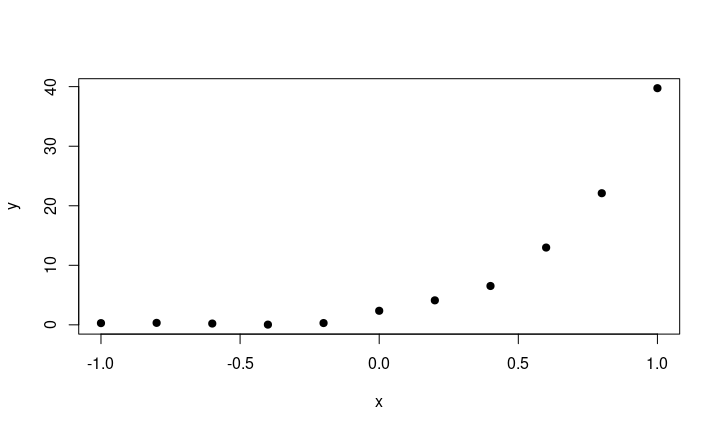

## Ejemplo (continuación)

Miremos si la relación es exponencial.

Para ello, consideramos los puntos \((x_k,\ln (y_k))\):

| \(x\) | \(\ln(y)\) |
| --- | --- |
| \(-1\) | \(-1.2445858\) |
| \(-0.8\) | \(-1.1019877\) |
| \(-0.6\) | \(-1.5213638\) |
| \(-0.4\) | \(-3.2918371\) |
| \(-0.2\) | \(-1.2018288\) |
| \(0\) | \(0.8587831\) |

## Ejemplo (continuación)

| \(x\) | \(\ln(y)\) |
| --- | --- |
| \(0.2\) | \(1.4143467\) |
| \(0.4\) | \(1.8757245\) |
| \(0.6\) | \(2.5633219\) |
| \(0.8\) | \(3.0958055\) |
| \(1\) | \(3.6824718\) |

Si hallamos la mejor aproximación lineal de la nube de puntos anterior obtenemos la recta siguiente: \[ \log(y)=0.4662591+3.0287189\cdot x. \] La relación exponencial buscada es la siguiente: \[ y=\mathrm{e}^{0.4662591}\cdot\mathrm{e}^{3.0287189\cdot x}=1.59402\cdot\mathrm{e}^{3.0287189\cdot x}. \]

## Ejemplo (continuación)

En el gráfico siguiente se observa la nube de puntos original junto con la función exponencial hallada:

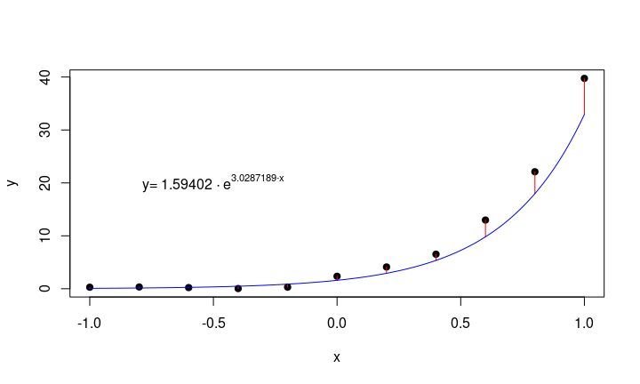

## Ejemplo (continuación)

El error cometido es el siguiente: \[ \begin{align*} E(a,b) = & E(3.0287189,1.59402)=\sum_{k=1}^{11} \left(y_k-1.59402\cdot\mathrm{e}^{3.0287189\cdot x_k}\right)^2\\ = & (0.2880602-1.59402\cdot\mathrm{e}^{3.0287189\cdot (-1)})^2+(0.3322101-1.59402\cdot\mathrm{e}^{3.0287189\cdot (-0.8)})^2 \\ & \quad + (0.2184138-1.59402\cdot\mathrm{e}^{3.0287189\cdot (-0.6)})^2+(0.0371855-1.59402\cdot\mathrm{e}^{3.0287189\cdot (-0.4)})^2\\ & \quad + (0.3006439-1.59402\cdot\mathrm{e}^{3.0287189\cdot (-0.2)})^2+(2.3602867-1.59402\cdot\mathrm{e}^{3.0287189\cdot 0})^2\\ & \quad + (4.1137981-1.59402\cdot\mathrm{e}^{3.0287189\cdot 0.2})^2+(6.525545-1.59402\cdot\mathrm{e}^{3.0287189\cdot 0.4})^2\\ & \quad + (12.9788606-1.59402\cdot\mathrm{e}^{3.0287189\cdot 0.6})^2+(22.1050362-1.59402\cdot\mathrm{e}^{3.0287189\cdot 0.8})^2\\ & \quad + (39.7445124-1.59402\cdot\mathrm{e}^{3.0287189\cdot 1})^2\\= & 77.2082768. \end{align*} \] En este ejemplo, no hemos resuelto el problema original que era hallar los valores \(a\) y \(b\) que minimicen la función error: \[ E(a,b)=\sum_{k=1}^m \left(y_k-b\mathrm{e}^{a x_k}\right)^2, \] De hecho, podemos comprobar que los valores \(a\) y \(b\) hallados no son los óptimos.

## Ejemplo (continuación)

Efectivamente, si consideramos \(a=3\) y \(b=2\), obtenemos un error mucho menor:

\[ \begin{align*} E(a,b) = & E(3,2)=\sum_{k=1}^{11} \left(y_k-2\cdot\mathrm{e}^{3\cdot x_k}\right)^2\\ = & (0.2880602-2\cdot\mathrm{e}^{3\cdot (-1)})^2+(0.3322101-2\cdot\mathrm{e}^{3\cdot (-0.8)})^2 \\ & \quad + (0.2184138-2\cdot\mathrm{e}^{3\cdot (-0.6)})^2+(0.0371855-2\cdot\mathrm{e}^{3\cdot (-0.4)})^2\\ & \quad + (0.3006439-2\cdot\mathrm{e}^{3\cdot (-0.2)})^2+(2.3602867-2\cdot\mathrm{e}^{3\cdot 0})^2\\ & \quad + (4.1137981-2\cdot\mathrm{e}^{3\cdot 0.2})^2+(6.525545-2\cdot\mathrm{e}^{3\cdot 0.4})^2\\ & \quad + (12.9788606-2\cdot\mathrm{e}^{3\cdot 0.6})^2+(22.1050362-2\cdot\mathrm{e}^{3\cdot 0.8})^2\\ & \quad + (39.7445124-2\cdot\mathrm{e}^{3\cdot 1})^2\\= & 2.3479569. \end{align*} \] Lo único que hemos hecho es transformar la nube de puntos \((x_k,y_k),\) \(k=1,\ldots,m\) en otra nube de puntos \((x_k,\ln y_k)\), \(k=1,\ldots,m\) de la que sabemos hallar la aproximación lineal por mínimos cuadrados.

Ahora bien, dicha aproximación lineal, tal como hemos visto, no optimiza nuestro problema original.

Para optimizar nuestro problema original, tendríamos que resolver un sistema no lineal.

En un próximo capítulo, aprenderemos técnicas para resolver sistemas no lineales.

## Aproximación de funciones continuas

## Introducción

Como ya comentamos al principio del tema, vamos a intentar resolver el problema siguiente:

Problema de aproximación de funciones continuas.

Dada una función \(f\in {\cal C}[a,b]\) una **función continua en un intervalo \([a,b]\)**, vamos a hallar una función \(\hat{f}\) en un determinado **espacio de funciones** tal que minimice el **error cuadrático** siguiente: \[ E(\hat{f})=\int_a^b (f(x)-\hat{f}(x))^2\, dx. \]

Entonces, en lugar de considerar una **nube de puntos discreta** \((x_k,y_k)\), \(k=1,\ldots,m\), consideramos todo un “conjunto continuo” de puntos \((x,f(x))\), \(x\in [a,b]\), y queremos hallar una **aproximación** \(\hat{f}(x)\), \(x\in [a,b]\) que minimice la **función error** anterior.

Como podemos observar, hemos “cambiado” los **sumatorios** por **integrales** ya que una **integral** puede definirse intuitivamente como un **sumatorio continuo**.

## Aproximación polinomial

En el caso en que el **espacio de funciones** sea el conjunto de polinomios de grado menor o igual que un cierto \(n\), tendremos el problema de **aproximación polinomial**:

Problema de aproximación polinomial de funciones continuas.

Dada una función \(f\in {\cal C}[a,b]\) una **función continua en un intervalo \([a,b]\)**, vamos a hallar un **polinomio** \(P(x)=a_n x^n+a_{n-1}x^{n-1}+\cdots +a_1 x+a_0\) de grado menor o igual que \(n\) tal que minimice el **error cuadrático** siguiente: \[ E(a_0,a_1,\ldots,a_n)=\int_a^b (f(x)-P(x))^2\, dx =\int_a^b \left(f(x)-\sum_{k=0}^n a_k x^k\right)^2\, dx. \]

La **función error** puede escribirse como: \[ E(a_0,a_1,\ldots,a_n)=\int_a^b f(x)^2\, dx-2\sum_{k=0}^n a_k\int_a^b x^k f(x)\, dx+\int_a^b\left(\sum_{k=0}^n a_k x^k\right)^2\, dx. \]

## Aproximación polinomial

Como la **función error** \(E\) depende de \(n+1\) variables, el **mínimo** debe verificar el sistema de ecuaciones siguiente: \[ \begin{align*} \frac{\partial E}{\partial a_j}(a_0,a_1,\ldots,a_n)= 0,\ \Rightarrow & -2\int_a^b x^j f(x)\, dx+2\sum_{k=0}^n a_k\int_a^b x^{j+k}\, dx =0,\ \Rightarrow \\ \sum_{k=0}^n a_k\int_a^b x^{j+k}\, dx = & \int_a^b x^j f(x)\, dx,\ \Rightarrow \\ \sum_{k=0}^n a_k\left[\frac{x^{j+k+1}}{j+k+1}\right]_a^b = & \int_a^b x^j f(x)\, dx,\ \Rightarrow \\ \sum_{k=0}^n \left(\frac{b^{j+k+1}-a^{j+k+1}}{j+k+1}\right)\cdot a_k = & \int_a^b x^j f(x)\, dx, \end{align*} \] para \(j=0,\ldots,n\).

## Sistema de ecuaciones a resolver

Obtenemos que el **vector de coeficientes** \(\mathbf{a}=(a_0,a_1,\ldots,a_n)\) verifica el **sistema lineal siguiente** denominado **sistema de ecuaciones normales**: \[ \mathbf{A}\mathbf{a}=\mathbf{b}, \] donde \(\mathbf{A}=(a_{ij})_{i,j=1,\ldots,n+1}\) es una matriz \((n+1)\times (n+1)\) de componentes \(a_{ij}=\frac{b^{i+j-1}-a^{i+j-1}}{i+j-1}\) y \(\mathbf{b}=(b_i)_{i=1,\ldots,n+1}\) es el término independiente de componentes \(b_i =\int_a^b x^{i-1} f(x)\, dx\):

\[ \mathbf{A}=\begin{bmatrix}b-a&\frac{b^2-a^2}{2}&\ldots&\frac{b^{n+1}-a^{n+1}}{n+1} \\\frac{b^2-a^2}{2}&\frac{b^3-a^3}{3}&\ldots&\frac{b^{n+2}-a^{n+2}}{n+2} \\\vdots&\vdots&\ddots&\vdots \\\frac{b^{n+1}-a^{n+1}}{n+1}&\frac{b^{n+2}-a^{n+2}}{n+2}&\ldots&\frac{b^{2n+1}-a^{2n+1}}{2n+1} \\\end{bmatrix},\ \mathbf{b}=\begin{bmatrix}\int_a^b f(x)\,dx\\ \int_a^b xf(x)\,dx\\\vdots\\\int_a^b x^{n}f(x)\,dx\end{bmatrix} \]

## Sistema de ecuaciones a resolver

La matriz del **sistema lineal anterior** se denomina **matriz de Hilbert**.

Dicha matriz tiene un **número de condición** muy elevado, hecho que hace que aumenten los **errores de redondeo** de la solución. Ver el curso **Métodos numéricos con Python - Álgebra lineal numérica** para más detalles.

La tabla siguiente muestra el **número de condición** de la **matriz de Hilbert** para \(a=0\) y \(b=1\) usando la **norma euclídea**:

## Sistema de ecuaciones a resolver

| \(n\) | \(\mu(A)\) |
| --- | --- |
| \(3\) | \(15513.7387389\) |
| \(4\) | \(476607.2502425\) |
| \(5\) | \(14951058.6416385\) |
| \(6\) | \(475367356.540476\) |
| \(7\) | \(15257575617.1347\) |
| \(8\) | \(493153337423.307\) |

## Aproximación polinomial

Vamos a resolver la **aproximación polinomial** de una forma **computacional** más **eficiente**.

Antes de hacerlo, necesitamos unas definiciones previas:

Definición de conjunto de funciones linealmente independientes.

Sean \(f_0,f_1\ldots,f_n\), \(n+1\) funciones definidas en el intervalo \([a,b]\). Diremos que el conjunto de funciones \(\{f_0,f_1,\ldots,f_n\}\) es **linealmente independiente** si la igualdad siguiente: \[ \lambda_0 f_0(x)+\lambda_1 f_1(x)+\cdots +\lambda_n f_n(x)=0, \] para cualquier \(x\in [a,b]\) implica que \(\lambda_0 =\lambda_1 =\cdots =\lambda_n =0\). En caso contrario, se dice que el conjunto de funciones es **linealmente dependiente**.

El resultado siguiente dice que cualquier conjunto de \(n+1\) polinomios de grado diferente es **linealmente independiente**:

## Polinomios linealmente independientes

Proposición: \(n+1\) polinomios de grados diferentes son linealmente independientes.

Sean \(P_0(x),P_1(x),\ldots,P_n(x)\), \(n+1\) polinomios donde el polinomio \(P_j(x)\) tiene grado \(j\), \(j=0,1,\ldots,n\). Entonces el conjunto de funciones polinómicas \(\{P_0(x),P_1(x),\ldots,P_n(x)\}\) es **linealmente independiente**.

**Demostración**

Sean \(\lambda_0,\lambda_1,\ldots,\lambda_n\), \(n+1\) números reales tal que: \[ \lambda_0 P_0(x)+\lambda_1 P_1(x)+\cdots +\lambda_n P_n(x)=0, \] para cualquier \(x\in [a,b]\).

Sea \(P(x)\) el polinomio \(P(x)=\lambda_0 P_0(x)+\lambda_1 P_1(x)+\cdots +\lambda_n P_n(x)\) de grado menor o igual que \(n\) que vale \(0\) en cualquier punto del intervalo \([a,b]\).

Entonces \(P(x)\equiv 0\) ya que como tiene más de \(n\) ceros, el único polinomio de grado menor o igual que \(n\) que tiene más de \(n\) ceros es el polinomio \(P(x)\equiv 0\).

Como \(P(x)\) es el polinomio idénticamente nulo, todos los coeficientes de \(x^j\) serán \(0\) para \(j=0,1,\ldots,n\).

## Demostración de la proposición

En particular, el coeficiente de \(x^n\) será \(0\) pero el único término que contiene \(x^n\) en la expresión \(P(x)=\lambda_0 P_0(x)+\lambda_1 P_1(x)+\cdots +\lambda_n P_n(x)\) es \(\lambda_n P_n(x)\). Por tanto, \(\lambda_n=0\).

Entonces \(P(x)=\lambda_0 P_0(x)+\lambda_1 P_1(x)+\cdots +\lambda_{n-1}P_{n-1}(x)\). Razonando de la misma manera anterior pero en lugar de \(x^n\), consideramos \(x^{n-1}\), tendremos que \(\lambda_{n-1}=0\).

Y así sucesivamente hasta llegar a la conclusión que \(\lambda_j=0,\ j=0,1,\ldots,n\), tal como queríamos demostrar.

Una consecuencia de la proposición anterior es la siguiente:

Proposición. Base de polinomios para el espacio vectorial de los polinomios de grado menor o igual que \(n\).

Sean \(P_0(x),P_1(x),\ldots,P_n(x)\), \(n+1\) polinomios donde el polinomio \(P_j(x)\) tiene grado \(j\), \(j=0,1,\ldots,n\). Entonces el conjunto de funciones polinómicas \(\{P_0(x),P_1(x),\ldots,P_n(x)\}\) forman una base para el espacio vectorial formado por los polinomios de grado menor o igual que \(n\).

## Demostración de la proposición

Hay de demostrar lo siguiente:

- El conjunto de polinomios \(\{P_0(x),P_1(x),\ldots,P_n(x)\}\) es **linealmente independiente** que ya está probado en la proposición anterior.
- Cualquier polinomio \(P(x)\) de grado menor o igual que \(n\) puede escribirse como combinación lineal de \(P_0(x),P_1(x),\ldots,P_n(x)\), es decir, existen valores reales \(\lambda_0,\lambda_1,\ldots,\lambda_n\) tal que \[ P(x)=\lambda_0 P_0(x)+\lambda_1 P_1(x)+\cdots +\lambda_n P_n(x). \] Para ello, escribimos \(P_j(x)\), \(j=0,\ldots,n\) y \(P(x)\) de la forma siguiente: \[ \begin{align*} P_j(x)=& a_{j,n} x^n+a_{j,n-1}x^{n-1}+\cdots + a_{j,1}x+a_{j,0},\\ P(x)=&a_n x^n+a_{n-1}x^{n-1}+\cdots + a_1 x+a_0, \end{align*} \] donde \(j=0,\ldots,n\).

El coeficiente de \(x^n\) en la expresión \(\lambda_0 P_0(x)+\lambda_1 P_1(x)+\cdots +\lambda_n P_n(x)\) es \(\lambda_n\cdot a_{n,n}\).

Por tanto, como el coeficiente de \(x^n\) en \(P(x)\) y \(\lambda_0 P_0(x)+\lambda_1 P_1(x)+\cdots +\lambda_n P_n(x)\) deben ser iguales, tenemos que \(a_n=\lambda_n a_{n,n}\), es decir, \(\lambda_n =\frac{a_n}{a_{n,n}}\) ya que \(a_{n,n}\neq 0\) al ser \(P_n(x)\) un polinomio de grado \(n\).

## Demostración de la proposición

En general, suponemos calculados \(\lambda_n,\ldots,\lambda_{j+1}\). El coeficiente de \(x^j\) en la expresión \(\lambda_0 P_0(x)+\lambda_1 P_1(x)+\cdots +\lambda_n P_n(x)\) es \(\lambda_n\cdot a_{n,j}+\lambda_{n-1}\cdot a_{n-1,j}+\cdots +\lambda_{j+1}a_{j+1,j}+\lambda_j a_{j,j}\).

Por tanto, como el coeficiente de \(x^j\) en \(P(x)\) y \(\lambda_0 P_0(x)+\lambda_1 P_1(x)+\cdots +\lambda_n P_n(x)\) deben ser iguales, tenemos que \[ a_j=\lambda_n\cdot a_{n,j}+\lambda_{n-1}\cdot a_{n-1,j}+\cdots +\lambda_{j+1}a_{j+1,j}+\lambda_j a_{j,j}, \] es decir, \[ \lambda_j =\frac{a_j-(\lambda_n\cdot a_{n,j}+\lambda_{n-1}\cdot a_{n-1,j}+\cdots +\lambda_{j+1}a_{j+1,j})}{a_{j,j}}, \] ya que \(a_{j,j}\neq 0\) al ser \(P_j(x)\) un polinomio de grado \(j\).

Quedan, por tanto, calculados \(\lambda_j\), \(j=0,1,\ldots,n\) tal como queríamos demostrar.

## Generalización de la aproximación polinomial

Vamos a generalizar la **aproximación polinomial** de una función en términos de **funciones peso**.

Una **función peso** es una función que asocia más o menos **importancia** a los puntos del intervalo \([a,b]\):

Definición de función peso \(w\).

Diremos que una función \(w\) definida en el intervalo \((a,b)\) (¡ojo!, basta **abierto**) es una **función peso** si

- la función \(w(x)\) es **integrable** en el intervalo \([a,b]\). Por tanto, admitimos **integración impropia convergente**. Ver el curso **Curso Completo de Cálculo en una variable: de cero a experto** para más detalles,
- la función \(w(x)\) debe ser **positiva**, \(w(x)\geq 0\),
- la función \(w(x)\not\equiv 0\) no puede ser **idénticamente nula** en cualquier subintervalo \(I\subseteq [a,b]\).

## Ejemplo de función peso

Consideremos el intervalo \([-1,1]\) con la función siguiente \(w(x)=\frac{1}{\sqrt{1-x^2}}\) definida en el intervalo abierto \((-1,1)\).

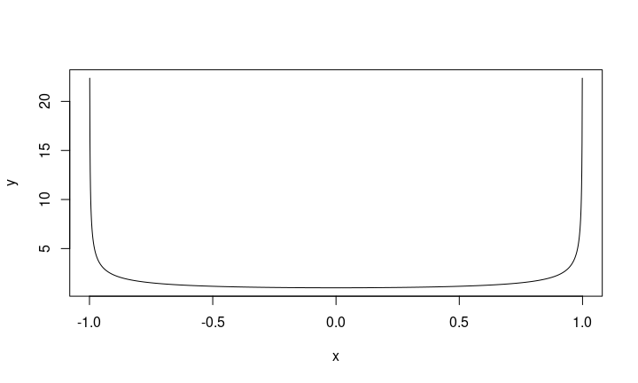

## Ejemplo de función peso

Dicha función:

- es integrable en el intervalo \([-1,1]\) ya que: \[ \int_{-1}^1 w(x)\, dx=\int_{-1}^1 \frac{1}{\sqrt{1-x^2}}\, dx =[\arcsin x]_{-1}^1 =\arcsin 1-\arcsin (-1)=\frac{\pi}{2}-\left(-\frac{\pi}{2}\right)=\pi. \]
- es positiva ya que \(1-x^2 \geq 0\), si \(x\in [-1,1]\) y, por tanto, \(w(x)=\frac{1}{\sqrt{1-x^2}}\geq 0\),
- sea \(I\) cualquier subintervalo en \([-1,1]\), como \(w(x)\neq 0\), para cualquier \(x\in (-1,1)\), tendremos que \(w(x)\not\equiv 0\) para \(x\in I\).

## Problema de aproximación usando pesos

Si tenemos una **función peso** \(w(x)\) en el intervalo \([a,b]\) y una base \(P_0(x),P_1(x),\ldots,P_n(x)\) de polinomios del **espacio vectorial de polinomios de grado menor o igual que \(n\)**, podemos generalizar el problema de **aproximación polinomial** de la forma siguiente:

Problema de aproximación polinomial de funciones continuas.

Dada una función \(f\in {\cal C}[a,b]\) una **función continua en un intervalo \([a,b]\)** y una **función peso \(w(x)\)** vamos a hallar un **polinomio** \(P(x)=a_n P_n(x)+a_{n-1}P_{n-1}(x)+\cdots +a_1 P_1(x)+a_0 P_0(x)\) de grado menor o igual que \(n\) tal que minimice el **error cuadrático** siguiente: \[ \begin{align*} E(a_0,a_1,\ldots,a_n)= & \int_a^b w(x) (f(x)-P(x))^2\, dx \\ = & \int_a^b w(x)\left(f(x)-\sum_{k=0}^n a_k P_k(x)\right)^2\, dx. \end{align*} \]

## Cálculo de los coeficientes \(a_j\), \(j=0,1,\ldots,n\)

Observación.

El problema de aproximación original se obtiene considerando la **función peso** \(w(x)\equiv 1\) y como **base de polinomios** del **espacio vectorial de polinomios de grado menor o igual que \(n\)**, \(P_j(x)=x^j\), \(j=0,\ldots,n\).

Siguiendo un procedimiento similar, podemos escribir la **función error** de la forma siguiente: \[ \begin{align*} E(a_0,a_1,\ldots,a_n)= & \int_a^b w(x)f(x)^2\, dx-2\sum_{k=0}^n a_k\int_a^b w(x)P_k(x) f(x)\, dx\\ & \quad +\int_a^b w(x)\left(\sum_{k=0}^n a_k P_k(x)\right)^2\, dx. \end{align*} \]

## Cálculo de los coeficientes \(a_j\), \(j=0,1,\ldots,n\)

A continuación, recordemos que para hallar los coeficientes \(a_j\), \(j=0,1,\ldots,n\), hemos de resolver el siguiente sistema de ecuaciones: Como la **función error** \(E\) depende de \(n+1\) variables, el **mínimo** debe verificar el sistema de ecuaciones siguiente: \[ \begin{align*} & \frac{\partial E}{\partial a_j}(a_0,a_1,\ldots,a_n)= 0,\ \Rightarrow \\ & -2\int_a^b w(x)P_j(x) f(x)\, dx+2\sum_{k=0}^n a_k\int_a^b w(x) P_j(x)P_k(x)\, dx = 0,\ \Rightarrow \\ & \sum_{k=0}^n a_k\int_a^b w(x) P_j(x)P_k(x)\, dx = \int_a^b w(x)P_j(x) f(x)\, dx, \end{align*} \] donde \(j=0,1,\ldots,n\).

## Sistema de ecuaciones a resolver

Obtenemos que el **vector de coeficientes** \(\mathbf{a}=(a_0,a_1,\ldots,a_n)\) verifica el **sistema lineal siguiente** denominado **sistema de ecuaciones normales**: \[ \mathbf{A}\mathbf{a}=\mathbf{b}, \] donde \(\mathbf{A}=(a_{ij})_{i,j=1,\ldots,n+1}\) es una matriz \((n+1)\times (n+1)\) de componentes \(a_{ij}=\int_a^b w(x)P_{i-1}(x)P_{j-1}(x)\, dx\) y \(\mathbf{b}=(b_i)_{i=1,\ldots,n+1}\) es el término independiente de componentes \(b_i =\int_a^b w(x) P_{i-1}(x) f(x)\, dx\):

\[ \mathbf{A}=\begin{bmatrix}\int_a^b w(x)P_{0}(x)^2\, dx&\int_a^b w(x)P_{0}(x)P_1(x)\, dx&\ldots&\int_a^b w(x)P_{0}(x)P_n(x)\, dx \\\int_a^b w(x)P_{0}(x)P_1(x)\, dx&\int_a^b w(x)P_{1}(x)^2\, dx&\ldots&\int_a^b w(x)P_{1}(x)P_n(x)\, dx \\\vdots&\vdots&\ddots&\vdots \\\int_a^b w(x)P_{0}(x)P_n(x)\, dx&\int_a^b w(x)P_{1}(x)P_n(x)\, dx&\ldots&\int_a^b w(x)P_n(x)^2\, dx \\\end{bmatrix},\ \mathbf{b}=\begin{bmatrix}\int_a^b w(x)P_0(x)f(x)\,dx\\ \int_a^b w(x)P_1(x)f(x)\,dx\\\vdots\\\int_a^b w(x)P_n(x)f(x)\,dx\end{bmatrix}. \]

## Funciones ortogonales

Aquí viene la idea clave: si pudiésemos elegir la **base de polinomios** \(P_0(x),P_1(x),\ldots,P_n(x)\) tal que: \[ \int_a^b w(x)P_i(x)P_j(x)=0, \] para \(i\neq j\) y \(i,j=0,\ldots,n+1\), la matriz \(\mathbf{A}\) del sistema lineal anterior sería **diagonal** y la resolución del sistema sería inmediata: \[ a_j = \frac{b_{j+1}}{a_{j+1,j+1}}=\frac{\int_a^b w(x)P_{j}(x)f(x)\,dx}{\int_a^b w(x)P_{j}(x)^2\, dx}, \] \(j=0,\ldots,n\).

## Funciones ortogonales

La base de funciones que cumplan la condición anterior \(\int_a^b w(x)P_i(x)P_j(x)=0,\) para \(i\neq j\), \(i,j=0,\ldots,n\) se denominan base de funciones **ortogonales**:

Definición de funciones ortogonales.

Diremos que un conjunto de funciones \(\{f_0,f_1,\ldots,f_n\}\) es un **conjunto ortogonal de funciones** en el intervalo \([a,b]\) con respecto la **función peso** \(w(x)\) si: \[ \int_a^b w(x)f_i(x)f_j(x)\, dx=\begin{cases}0, & \mbox{si }i\neq j,\\ c_j>0, & \mbox{si } i=j.´\end{cases} \] Si además, \(c_0=\cdots = c_n=1\), el conjunto de funciones se denomina **conjunto ortonormal de funciones**.

## Funciones ortogonales

El siguiente resultado dice cómo calcular la base de polinomios **ortogonales** dado un intervalo \([a,b]\) y una **función peso** \(w(x)\).

Teorema: construcción de polinomios ortogonales.

Sea \(\{P_0,P_1,\ldots,P_n\}\) el conjunto de polinomios definidos de la forma siguiente: \[ P_0(x)\equiv 1,\ P_1(x)=x-\alpha_1, \] para \(x\in [a,b]\) y \(\alpha_1 = \frac{\int_a^b x w(x)\, dx}{\int_a^b w(x)\, dx},\) y para \(k\geq 2\), \[ P_k(x)=(x-\alpha_k)P_{k-1}(x)-\beta_k P_{k-2}(x), \] para \(x\in [a,b]\) y \(\alpha_k=\frac{\int_a^b x w(x)P_{k-1}(x)^2\, dx}{\int_a^b w(x)P_{k-1}(x)^2\, dx},\) \(\beta_k=\frac{\int_a^b x w(x)P_{k-1}(x)P_{k-2}(x)\, dx}{\int_a^b w(x)P_{k-2}(x)^2\, dx}.\)

Entonces el conjunto anterior de polinomios es un **conjunto ortogonal** con respecto a la **función peso** \(w(x)\).

## Demostración del Teorema

Antes de demostrar el Teorema, fijémonos en lo siguiente:

1. el grado del polinomio \(P_k(x)\) es \(k\). Basta usar un proceso inductivo y observar que el grado de \(P_0(x)\equiv 1\) es \(0\) y como \(P_k(x)=(x-\alpha_k)P_{k-1}(x)-\beta_k P_{k-2}(x),\) usando que el grado de \(P_{k-1}(x)\) es \(k-1\) y el grado de \(P_{k-2}\) es \(k-2\), tendremos que el grado de \(P_{k}(x)\) sería \(k\).
2. el conjunto de polinomios \(\{P_0,\ldots,P_k\}\) forma una base del espacio vectorial de polinomios de grado menor o igual que \(k\) usando el hecho anterior y una proposición demostrada anteriormente.
3. entonces si \(\int_a^b w(x)P_k(x)P_l(x)\, dx=0\), para \(l=0,\ldots,k-1\), podemos afirmar que \(\int_a^b w(x)P_k(x) P(x)\, dx=0\) para todo polinomio \(P(x)\) de grado menor o igual que \(k-1\) ya que, como hemos dicho antes, el conjunto \(\{P_0,\ldots,P_{k-1}\}\) forma una base del espacio vectorial de polinomios de grado menor o igual que \(k-1\) y podemos decir que existen \(c_0,\ldots,c_{k-1}\) tal que \(P(x)=c_0P_0(x)+c_1P_1(x)+\cdots +c_{k-1}P_{k-1}(x)\). Por tanto, \[ \int_a^b w(x)P_k(x) P(x)\, dx=\int_a^b w(x)P_k(x)\sum_{i=0}^{k-1}c_iP_i(x)\, dx=\sum_{i=0}^{k-1}\int_a^b w(x)P_k(x)P_i(x)\, dx=0, \] ya que todos los sumandos del sumatorio anterior son nulos.

## Demostración del Teorema

Demostrar que el conjunto \(\{P_0,P_1,\ldots,P_n\}\) es **ortogonal** es equivalente a demostrar que para todo \(k\), \(k=1,\ldots,n\) se cumple que: \[ \int_a^b w(x)P_k(x)P_l(x)\, dx=0, \] para \(l=0,\ldots,k-1\).

- \(k=1\): hemos de ver \(\int_a^b w(x)P_0(x)P_1(x)\, dx=0\): \[ \begin{align*} \int_a^b w(x)P_0(x)P_1(x)\, dx =&\int_a^b w(x)(x-\alpha_1)\, dx=\int_a^b x w(x)\, dx-\alpha_1\int_a^b w(x)\, dx\\ = & \int_a^b x w(x)\, dx- \frac{\int_a^b x w(x)\, dx}{\int_a^b w(x)\, dx}\cdot\int_a^b w(x)\, dx=0, \end{align*} \] tal como queríamos demostrar.

## Demostración del Teorema

- \(k>1\). Suponemos usando un proceso inductivo que para todo \(i,j\leq k-1\), \(i\neq j\) se cumple \(\int_a^b w(x)P_i(x)P_j(x)\, dx=0\). Hemos de ver que \(\int_a^b w(x)P_k(x)P_l(x)\, dx=0\), para \(l=0,\ldots,k-1\). Distingamos tres casos:
  - \(l\leq k-3\): en este caso: \[ \begin{align*} \int_a^b w(x)P_k(x)P_l(x)\, dx = & \int_a^b w(x)((x-\alpha_k)P_{k-1}(x)-\beta_k P_{k-2}(x))P_l(x)\, dx\\ = & \int_a^b w(x)((x-\alpha_k)P_{k-1}(x)P_l(x)\,dx -\beta_k \int_a^b w(x)P_{k-2}(x)P_l(x)\,dx \\ = &\int_a^b w(x)(x-\alpha_k)P_{k-1}(x)P_l(x)\,dx=\int_a^b w(x)x P_{k-1}(x)P_l(x)\,dx=0. \end{align*} \] La última integral es nula ya que \(xP_l(x)\) es un polinomio de grado menor o igual que \(k-2\) y usando la consideración 3. podemos afirmar por inducción que todo polinomio \(P(x)\) de grado menor o igual que \(k-2\) cumple \(\int_a^b w(x)P_{k-1}(x)P(x)\, dx=0.\)

## Demostración del Teorema

- - \(l=k-2\): en este caso: \[ \begin{align*} & \int_a^b w(x)P_k(x)P_{k-2}(x)\, dx = \int_a^b w(x)((x-\alpha_k)P_{k-1}(x)-\beta_k P_{k-2}(x))P_{k-2}(x)\, dx\\ = &\int_a^b w(x)(x-\alpha_k)P_{k-1}(x)P_{k-2}(x)\,dx-\beta_k \int_a^b w(x)P_{k-2}(x)^2\, dx\\ = & \int_a^b w(x)xP_{k-1}(x)P_{k-2}(x)\,dx-\beta_k \int_a^b w(x)P_{k-2}(x)^2\, dx\\ = & \int_a^b w(x)xP_{k-1}(x)P_{k-2}(x)\,dx-\frac{\int_a^b x w(x)P_{k-1}(x)P_{k-2}(x)\, dx}{\int_a^b w(x)P_{k-2}(x)^2\, dx}\cdot \int_a^b w(x)P_{k-2}(x)^2\, dx=0. \end{align*} \]

## Demostración del Teorema

- - \(l=k-1\): en este caso: \[ \begin{align*} & \int_a^b w(x)P_k(x)P_{k-1}(x)\, dx = \int_a^b w(x)((x-\alpha_k)P_{k-1}(x)-\beta_k P_{k-2}(x))P_{k-1}(x)\, dx\\ = &\int_a^b w(x)(x-\alpha_k)P_{k-1}(x)P_{k-1}(x)\,dx-\beta_k \int_a^b w(x)P_{k-2}(x) P_{k-1}(x)\, dx\\ = & \int_a^b w(x)xP_{k-1}(x)^2\,dx-\alpha_k\int_a^b w(x) P_{k-1}(x)^2\, dx\\ = & \int_a^b w(x)xP_{k-1}(x)^2\,dx-\frac{\int_a^b x w(x)P_{k-1}(x)^2\, dx}{\int_a^b w(x)P_{k-1}(x)^2\, dx}\cdot \int_a^b w(x)P_{k-1}(x)^2\, dx=0. \end{align*} \]

## Polinomios ortogonales

Observación.

Los polinomios ortogonales son **únicos** excepto por una **constante**.

Es decir, si \(\{P_0,P_1\ldots,P_n\}\) son \(n\) **polinomios ortogonales** definidos por el Teorema, también los son \(\{\gamma_0 P_0,\gamma_1 P_1\ldots,\gamma_n P_n\}\) donde \(\gamma_0,\gamma_1,\ldots,\gamma_n\) son \(n\) **constantes arbitrarias.**.

El Teorema ha realizado una “normalización” eligiendo los polinomios \(P_i(x)\) **mónicos**, es decir, el **coeficiente principal** o el coeficiente de \(x^i\) siempre vale \(1\), \(i=0,1,\ldots,n\).

## Polinomios ortogonales

Observación (continuación).

Ahora bien, las soluciones de las **ecuaciones normales** \((a_i)_{i=0,\ldots,n}\) dependen de los **polinomios ortogonales** elegidos, es decir, dependen de las \(\gamma_i\), \(i=0,1,\ldots,n\) de la forma siguiente:

si en lugar de considerar \(P_i\), consideramos \(\gamma_i P_i\), \(i=0,1,\ldots,n\): \[ \tilde{a}_i = \frac{\int_a^b w(x)\gamma_i P_{i}(x)f(x)\,dx}{\int_a^b w(x)\gamma_i^2 P_{i}(x)^2\, dx} =\frac{1}{\gamma_i} \frac{\int_a^b w(x)P_{i}(x)f(x)\,dx}{\int_a^b w(x)P_{i}(x)^2\, dx}=\frac{1}{\gamma_i}a_i, \] siendo \(a_i\) las soluciones de las **ecuaciones normales** considerando los polinomios ortogonales \(P_i\) y \(\tilde{a}_i\), las soluciones de las **ecuaciones normales** considerando los polinomios ortogonales \(\gamma_i P_i\), \(i=0,1,\ldots,n\).

## Polinomios ortogonales

Usando la demostración del teorema anterior, tenemos el corolario siguiente:

Corolario sobre un conjunto de polinomios ortogonales.

Sea \(\{P_0,P_1,\ldots,P_n\}\) el conjunto de polinomios **ortogonales** definidos según el Teorema anterior. Entonces:

- El conjunto de polinomios \(\{P_0,P_1,\ldots,P_n\}\) es **linealmente independiente**.
- Cualquier polinomio \(P(x)\) de grado menor que \(n\) (grado menor o igual que \(n-1\)) es **ortogonal** al polinomio \(P_n(x)\) del conjunto anterior: \[ \int_a^b w(x)P_n(x)P(x)\, dx=0. \]

## Ejemplo: polinomios de Legendre

Si consideramos el intervalo \([-1,1]\) y la función peso \(w(x)\equiv 1\), los polinomios ortogonales se denominan **polinomios de Legendre**. Calculemos los primeros: \[ \begin{align*} P_0(x)= & 1,\\ P_1(x)=& (x-\alpha_1)P_0(x)=x-\alpha_1,\ \alpha_1=\frac{\int_{-1}^1 x\,dx}{\int_{-1}^1 1\, dx}=0,\ \Rightarrow P_1(x)=x. \end{align*} \] El polinomio \(P_2(x)\) será: \[ P_2(x)= (x-\alpha_2)P_1(x)-\beta_2 P_0(x)=(x-\alpha_2)x-\beta_2, \] con \[ \begin{align*} \alpha_2 = & \frac{\int_{-1}^1 x\cdot P_1(x)^2\, dx}{\int_{-1}^1 P_1(x)^2\, dx}=\frac{\int_{-1}^1 x\cdot x^2\,dx}{\int_{-1}^1 x^2\, dx}=\frac{\int_{-1}^1 x^3\,dx}{\int_{-1}^1 x^2\, dx}=0,\\ \beta_2= & \frac{\int_{-1}^1 xP_1(x)P_0(x)\, dx}{\int_{-1}^1 P_0(x)^2\, dx}=\frac{\int_{-1}^1 x\cdot x\, dx}{\int_{-1}^1 1\, dx}=\frac{\int_{-1}^1 x^2\, dx}{\int_{-1}^1 1\, dx}=\frac{\frac{2}{3}}{2}=\frac{1}{3}. \end{align*} \] Por tanto \(P_2(x)=x^2-\frac{1}{3}\).

## Ejemplo: polinomios de Legendre

El polinomio \(P_3(x)\) será: \[ P_3(x)= (x-\alpha_3)P_2(x)-\beta_3 P_1(x)=(x-\alpha_3)\left(x^2-\frac{1}{3}\right)-\beta_3 x, \] con \[ \begin{align*} \alpha_3 = & \frac{\int_{-1}^1 x\cdot P_2(x)^2\, dx}{\int_{-1}^1 P_2(x)^2\, dx}=\frac{\int_{-1}^1 x\cdot \left(x^2-\frac{1}{3}\right)^2\,dx}{\int_{-1}^1 \left(x^2-\frac{1}{3}\right)^2\, dx}=0,\\ \beta_3= & \frac{\int_{-1}^1 xP_2(x)P_1(x)\, dx}{\int_{-1}^1 P_1(x)^2\, dx}=\frac{\int_{-1}^1 x\cdot \left(x^2-\frac{1}{3}\right)x\, dx}{\int_{-1}^1 x^2\, dx}=\frac{\frac{8}{45}}{\frac{2}{3}}=\frac{4}{15}. \end{align*} \] Por tanto \(P_3(x)=\left(x-0\right)\left(x^2-\frac{1}{3}\right)-\frac{4}{15} x=x^3-\frac{3}{5}x\).

Y así sucesivamente.

En el capítulo de **Derivación e Integración numérica** del curso **Métodos Numéricos con Python. Cálculo Numérico** se dan más fórmulas **recurrentes** y **explícitas** para calcular los **polinomios de Legendre**.

## Ejemplo

Consideremos la función \(f(x)=\cos(\pi x)\) donde \(x\in [-1,1]\).

Vamos a hallar la aproximación polinomial de grado \(3\) usando polinomios de Legendre, es decir, considerando \(w(x)\equiv 1\) como función peso.

El polinomio de aproximación de grado \(3\) será: \[ P(x)=a_3 P_3(x)+a_2 P_2(x)+a_1 P_1(x)+a_0 P_0(x), \] donde los \(P_i(x)\), \(i=0,1,2,3\) son los polinomios de Legendre: \[ P_0(x)=1,\ P_1(x)=x,\ P_2(x)=x^2-\frac{1}{3},\ P_3(x)=x^3-\frac{3}{5}x, \] y los coeficientes \(a_i\), \(i=0,1,2,3\) serán: \[ \begin{align*} a_0= & \frac{\int_{-1}^1 w(x)P_{0}(x)f(x)\,dx}{\int_{-1}^1 w(x)P_{0}(x)^2\, dx}=\frac{\int_{-1}^1 \cos(\pi x)\,dx}{\int_{-1}^1 1\, dx}=0,\\ a_1= & \frac{\int_{-1}^1 w(x)P_{1}(x)f(x)\,dx}{\int_{-1}^1 w(x)P_{1}(x)^2\, dx}=\frac{\int_{-1}^1 x\cos(\pi x)\,dx}{\int_{-1}^1 x^2\, dx}=0,\\ \end{align*} \]

## Ejemplo (continuación)

\[ \begin{align*} a_2= & \frac{\int_{-1}^1 w(x)P_{2}(x)f(x)\,dx}{\int_{-1}^1 w(x)P_{2}(x)^2\, dx}=\frac{\int_{-1}^1 \left(x^2-\frac{1}{3}\right)\cos(\pi x)\,dx}{\int_{-1}^1 \left(x^2-\frac{1}{3}\right)^2\, dx}=\frac{-\frac{4}{\pi^2}}{\frac{8}{45}}=-\frac{45}{2 \pi ^2},\\ a_3= & \frac{\int_{-1}^1 w(x)P_{3}(x)f(x)\,dx}{\int_{-1}^1 w(x)P_{3}(x)^2\, dx}=\frac{\int_{-1}^1 \left(x^3-\frac{3}{5}x\right)\cos(\pi x)\,dx}{\int_{-1}^1 \left(x^3-\frac{3}{5}x\right)^2\, dx}=0,\\ \end{align*} \] El polinomio de aproximación de grado como máximo \(3\) será: \(P(x)=-\frac{45}{2 \pi ^2}P_2(x)=-\frac{45}{2 \pi ^2}\left(x^2-\frac{1}{3}\right)\).

En el gráfico siguiente se muestra en negro la función \(f(x)\) y en rojo, la aproximación polinomial de grado \(3\) como máximo.

## Ejemplo

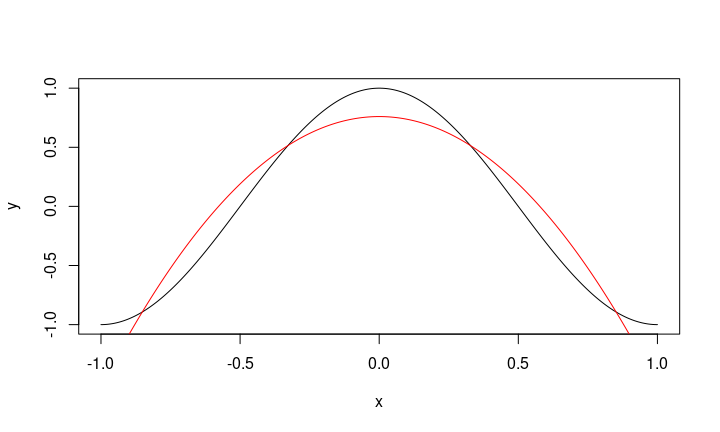

## Aproximación minimax

## Introducción

Una de las aproximaciones más usadas es la denominada **aproximación minimax** que consiste en resolver el problema siguiente:

Problema: aproximación minimax.

Sea \(f\in {\cal C}[a,b]\) una función continua en el intervalo \([a,b]\). Queremos hallar el polinomio \(\hat{P}_n(x)\) de grado menor o igual que \(n\) tal que minimice la **norma infinito** entre los **polinomios de grado menor o igual que \(n\)**, \(P_n\) es decir: \[ \|f-\hat{P}_n\|_\infty =\max_{x\in [a,b]}|f(x)-\hat{P}_n(x)|=\min_{P_n}\|f-P_n\|_\infty =\min_{P_n}\max_{x\in [a,b]}|f(x)-P_n(x)|. \] Dicho en otras palabras, queremos hallar el polinomio \(\hat{P}_n\) de grado menor o igual que \(n\) que **minimice** el **valor máximo** del **error** \(|f(x)-\hat{P}_n(x)|\) dentro del intervalo \([a,b]\) de entre todos los polinomios de grado menor o igual que \(n\).

La razón que se llame **aproximación minimax** está en la propia definición del problema: \(\min_{P_n}\max_{x\in [a,b]}|f(x)-P_n(x)|\).

## Caracterización de la aproximación minimax

El siguiente resultado nos caracteriza el polinomio buscado \(\hat{P}_n\):

Teorema: caracterización de la aproximación minimax.

El polinomio \(\hat{P}_n\) que **minimiza** la **norma infinito** \(\|f-P_n\|_\infty\) de entre todos los polinomios de grado menor o igual que \(n\) verifica lo siguiente:

la función **error** \(e_n(x)=f(x)-\hat{f}(x)\) tiene como mínimo \(n+2\) abscisas \(\xi_i\), \(i=0,1,\ldots,n+1\) ordenadas en el intervalo \([a,b]\) de la forma \(a\leq\xi_0<\xi_1<\cdots <\xi_{n+1}\leq b\) verificando la propiedad de **equioscilación**: \[ |e_n(\xi_j)|=\|e_n\|_\infty =\max_{x\in [a,b]}|e_n(x)|=\max_{x\in [a,b]}|f(x)-\hat{P}_n(x)|, \] para \(j=0,1,\ldots,n+1\), con **alternancia de signos**: \[ e_n(\xi_0)=-e_n(\xi_1)=\cdots = (-1)^{n+1}e_n(\xi_{n+1}). \]

## Caracterización de la aproximación minimax

Observación.

## Demostración del Teorema

La demostración se realiza por reducción al absurdo.

Supongamos que exista un polinomio \(\tilde{P}_n\) de grado menor o igual que \(n\) tal que \[ \|f-\tilde{P}_n\|_\infty < \|f-\hat{P}_n\|_\infty. \] En particular, si usamos la condición anterior en las abscisas \(\xi_j\), \(j=0,1,\ldots,n+1\), obtenemos: \[ |f(\xi_j)-\tilde{P}_n(\xi_j)|\leq \|f-\tilde{P}_n\|_\infty< \|f-\hat{P}_n\|_\infty = |f(\xi_j)-\hat{P}_n(\xi_j)|=\|e_n\|_\infty, \] para \(j=0,1,\ldots,n+1\).

## Demostración del Teorema (continuación)

A continuación consideramos el polinomio diferencia \(\tilde{P}_n(x)-\hat{P}_n(x)=(f(x)-\hat{P}_n(x))-(f(x)-\tilde{P}_n(x))\) de grado menor o igual que \(n\).

Dicho polinomio, usando que \(|f(\xi_j)-\tilde{P}_n(\xi_j)|<|f(\xi_j)-\hat{P}_n(\xi_j)|\), tiene el mismo signo en las abscisas \(\xi_j\) que la función error \(e_n(x)=f(x)-\hat{P}(x)\).

Como \(e_n(\xi_j)\) va alternando de signo en las abscisas \(\xi_j\) y como hay como mínimo \(n+2\) abscisas, podemos decir por el **Teorema de Bolzano** que el polinomio \(\tilde{P}_n(x)-\hat{P}_n(x)\) tiene como mínimo \(n+1\) ceros distintos.

Ahora bien, sabemos que todo polinomio de grado menor o igual que \(n\) tiene como máximo \(n\) ceros, hecho que contradice la afirmación anterior.

Por tanto, la suposición que hemos hecho es falsa y no puede existir un polinomio \(\tilde{P}_n(x)\) tal que \(\|f-\tilde{P}_n\|_\infty < \|f-\hat{P}_n\|_\infty\), tal como queríamos demostrar.

Proposición.

La **aproximación minimax** \(\hat{P}_n\) es **única**.

## Demostración de la proposición

Supongamos que hubiese dos soluciones a la aproximación minimax, \(\hat{P}_{1,n}\) y \(\hat{P}_{2,n}\). En este caso, se verificaría: \[ \|e_{n,1}\|_\infty =\|f-\hat{P}_{n,1}\|_\infty =\|e_{n,2}\|_\infty =\|f-\hat{P}_{n,2}\|_\infty. \]

Entonces, consideramos la función \[ R_n(x)=\hat{P}_{1,n}(x)-\hat{P}_{2,n}(x)=(f(x)-\hat{P}_{2,n}(x))-(f(x)-\hat{P}_{1,n}(x))=e_{n,2}(x)-e_{n,1}(x). \] Dicha función es un **polinomio de grado menor o igual que \(n\)** cuyo valor en las abscisas \(\xi_j\), \(j=0,1,\ldots,n+1\) vale: \[ R_n(\xi_j)=e_{n,2}(\xi_j)-e_{n,1}(\xi_j)=(-1)^{j+1}(\|e_{n,1}\|_\infty-\|e_{n,2}\|_\infty)=0, \] para \(j=0,1,\ldots,n+1\).

Entonces \(R_n\) es un polinomio de grado menor o igual que \(n\) con \(n+2\) ceros. El único polinomio de grado menor o igual que \(n\) que cumple lo anterior es el polinomio idénticamente nulo: \[ R_n(x)\equiv 0,\ \Rightarrow \hat{P}_{n,1}(x)=\hat{P}_{n,2}(x), \] tal como queríamos demostrar.

## Ejemplo

Consideremos la función \(f(x)=\mathrm{e}^x\) definida en el intervalo \([0,1]\).

Vamos a hallar la aproximación minimax de grado \(1\).

Es decir vamos a hallar la recta \(\hat{P}_1(x)=\hat{a}_0+\hat{a}_1 x\) tal que: \[ \|f-\hat{P}_1\|_\infty =\max_{x\in [0,1]}|\mathrm{e}^x-(\hat{a}_0+\hat{a}_1 x)|\leq \|f-P_1\|_\infty =\max_{x\in [0,1]}|\mathrm{e}^x-(a_0+a_1 x)|, \] para cualquier polinomio \(P_1(x)=a_0+a_1 x\), o para cualquier par de coeficientes \(a_0,a_1\).

Usando el Teorema anterior, hemos de hallar tres abscisas \(\xi_0,\xi_1,\xi_2\) tal que: \[ |e_1(\xi_j)|=\max_{x\in [0,1]}|\mathrm{e}^x-(\hat{a}_0+\hat{a}_1\xi_j)|,\ j=0,1,2, \] y además \(e_1(\xi_0)=-e_1(\xi_1)=e_1(\xi_2)\), o, \[ \mathrm{e}^{\xi_0}-(\hat{a}_0+\hat{a}_1\xi_0)=-(\mathrm{e}^{\xi_1}-(\hat{a}_0+\hat{a}_1\xi_1))=\mathrm{e}^{\xi_2}-(\hat{a}_0+\hat{a}_1\xi_2). \] Como las tres absisas \(\xi_0,\xi_1,\xi_2\) tienen que ser extremos absolutos de la función \(|\mathrm{e}^x-(\hat{a}_0+\hat{a}_1 x)|\) miremos primeros cuantos extremos relativos tiene la función \(e_1(x)=\mathrm{e}^x-(\hat{a}_0+\hat{a}_1 x)\): \[ e_1'(x)=0,\ \Rightarrow \mathrm{e}^x-\hat{a}_1 =0,\ \Rightarrow x=\ln(\hat{a}_1). \]

## Ejemplo

Como la función \(e_1(x)\) sólo tiene un extremo relativo en el intervalo \((0,1)\), tendremos que necesariamente las abscisas \(\xi_0\) y \(\xi_2\) tienen que coincidir con los extremos del intervalo.

Es decir, \(\xi_0=0,\ \xi_1 =\ln(\hat{a}_1),\ \xi_2=1\).

Por tanto, \[ \begin{align*} e_1(\xi_0)= & e_1(0)=1-\hat{a}_0 =-e_1(\xi_1)=-e_1(\ln(\hat{a}_1))=-(\hat{a}_1-(\hat{a}_0+\hat{a}_1\ln(\hat{a}_1)))=\hat{a}_0-\hat{a}_1(1-\ln(\hat{a}_1))\\ = & e_1(\xi_2)=e_1(1)=\mathrm{e}-(\hat{a}_0+\hat{a}_1). \end{align*} \] De la condición \(1-\hat{a}_0 =\mathrm{e}-(\hat{a}_0+\hat{a}_1)\) podemos hallar el coeficiente \(\hat{a}_1\): \[ \hat{a}_1 =\mathrm{e}-1\approx 1.7182818. \] De la condición \(1-\hat{a}_0 =\hat{a}_0-\hat{a}_1(1-\ln(\hat{a}_1))\) y usando que \(\hat{a}_1 =\mathrm{e}-1\) podemos hallar el coeficiente \(\hat{a}_0\): \[ \hat{a}_0 =\frac{1}{2}(1+\hat{a}_1(1-\ln(\hat{a}_1)))=\frac{1}{2}(1+(\mathrm{e}-1)\cdot (1-\ln(\mathrm{e}-1)))\approx 0.8940666. \] La mejor recta en la aproximación minimax de la función \(\mathrm{e}^x\) en el intervalo \([0,1]\) es: \[ \hat{P}_1(x)=\frac{1}{2}(1+(\mathrm{e}-1)\cdot (1-\ln(\mathrm{e}-1)))+(\mathrm{e}-1)x=0.8940666+1.7182818 x. \]

## Ejemplo (continuación)

El error de la aproximación minimax es relativamente sencillo de calcular: \[ \begin{align*} \|e_1\|_\infty = & \|\mathrm{e}^x-(\hat{a}_0+\hat{a}_1x)\|_\infty =|e_1(\xi_0)|=|1-\hat{a}_0|=\left|1-\left(\frac{1}{2}(1+(\mathrm{e}-1)\cdot (1-\ln(\mathrm{e}-1)))\right)\right|\\ = & \left|\frac{1}{2}(1-(\mathrm{e}-1)\cdot (1-\ln(\mathrm{e}-1)))\right|\approx 0.1059334. \end{align*} \]

La gráfica siguiente muestra la función \(f(x)=\mathrm{e}^x\) en negro y la aproximación lineal \(\hat{P}_1(x)\) en azul junto con los puntos \(\xi_i\), \(i=0,1,2\) en rojo mostrando la función error \(|e_1(\xi_i)|\), \(i=0,1,2\):

## Ejemplo (continuación)

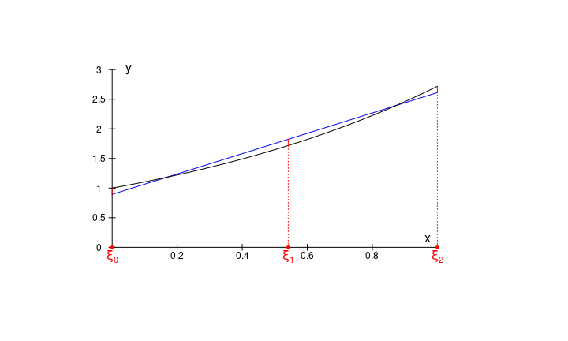

## Polinomios de Chebyschev

Los **polinomios de Chebyschev** \((T_k(x))_{k\geq 0}\) son los polinomios **ortogonales** correspondientes al intervalo \([-1,1]\) y a la **función peso** \(w(x)=\frac{1}{\sqrt{1-x^2}}\) y como veremos a continuación tienen un papel fundamental en la **aproximación minimax**.

En un ejemplo anterior, demostramos que dicha función peso cumplía las propiedades correspondientes.

Aunque los **polinomios de Chebyschev** se pueden definir a partir de la **recurrencia siguiente** tal como hemos visto: \[ \begin{align*} T_0(x)= & 1,\\ T_1(x)= & x-\alpha_1,\ \alpha_1 = \frac{\int_{-1}^1 \frac{x}{\sqrt{1-x^2}}\, dx}{\int_{-1}^1 \frac{1}{\sqrt{1-x^2}}\, dx}=0,\ \Rightarrow T_1(x)=x, \end{align*} \]

## Polinomios de Chebyschev

\[ T_k(x) = (x-\alpha_k)T_{k-1}(x)-\beta_k T_{k-2}(x), \] donde \[ \alpha_k =\frac{\int_{-1}^1 \frac{x}{\sqrt{1-x^2}}T_{k-1}(x)^2\, dx}{\int_{-1}^1 \frac{1}{\sqrt{1-x^2}} T_{k-1}(x)^2\, dx},\quad \beta_k =\frac{\int_{-1}^1 \frac{x}{\sqrt{1-x^2}}T_{k-1}(x) T_{k-2}(x)\, dx}{\int_{-1}^1 \frac{1}{\sqrt{1-x^2}} T_{k-2}(x)^2\, dx}, \] vamos a definirlos de la siguiente manera mucho más simple y más fácil de trabajar: \[ T_n(x)=\cos(n\arccos(x)),\ n\geq 0. \]

## Polinomios de Chebyschev

Teorema. Expresión de los polinomios de Chebyschev.

Los polinomios de Chebyschev cumplen la expresión siguiente: \[ T_n(x)=\cos(n\arccos(x)),\ n\geq 0, \] junto con la recurrencia: \[ T_{n+1}(x)=2xT_n(x)-T_{n-1}(x). \]

## Polinomios de Chebyschev

Observación.

Queremos realizar una aclaración. Cuando decimos que los **polinomios de Chebyschev** se pueden escribir como \(T_n(x)=\cos(n\arccos(x))\) estamos diciendo que **salvo una constante**, se obtienen los **polinomios de Chebyschev** dados por la **recurrencia general en los polinomios ortogonales**.

Recordemos que los **polinomios ortogonales** vistos por la **recurrencia general** son **mónicos**.

Sin embargo, veremos que los polinomios dados por la expresión \(T_n(x)=\cos(n\arccos(x))\) no lo son. De hecho, veremos que el **coeficiente principal** o el coeficiente de \(x^n\) del polinomio \(T_n(x)\) será \(2^{n-1}\).

Pasemos, pues, a demostrar que efectivamente los **polinomios de Chebyschev salvo una constante** se pueden definir de la forma anterior.

## Demostración del Teorema

Para \(n=0\), obtenemos \(T_0(x)=\cos(0\arccos(x))=\cos(0)=1\) y para \(n=1\), \(T_1(x)=\cos(\arccos(x))=x\).

Por tanto, la expresión és válida para \(n=0,1\).

A continuación, veamos que si definimos los polinomios de Chebyschev como en el Teorema, se cumple la recurrencia siguiente: \[ T_{n+1}(x)=2xT_n(x)-T_{n-1}(x). \] Efectivamente, \[ \begin{align*} T_{n+1}(x)= & \cos((n+1)\arccos(x))=\cos(n\arccos(x)+\arccos(x)),\\ T_{n-1}(x)= & \cos((n-1)\arccos(x))=\cos(n\arccos(x)-\arccos(x)). \end{align*} \] Llamando \(\theta=\arccos(x)\) y usando la relación trigonométrica \(\cos(n\theta \pm \theta)=\cos(\theta)\cos(n\theta)\mp\sin(\theta)\sin(n\theta)\), tenemos que: \[ \begin{align*} T_{n+1}(x)= &\cos(n\theta +\theta)=\cos(\theta)\cos(n\theta)-\sin(\theta)\sin(n\theta)=xT_n(x)-\sin(\theta)\sin(n\theta),\\ T_{n-1}(x)= & \cos(n\theta-\theta)=\cos(\theta)\cos(n\theta)+\sin(\theta)\sin(n\theta)=xT_n(x)+\sin(\theta)\sin(n\theta), \end{align*} \] usando que \(x=\cos(\theta).\)

Sumando las dos expresiones anteriores tenemos que: \[ T_{n+1}(x)+T_{n-1}(x)=2xT_n(x),\ \Rightarrow T_{n+1}(x)=2xT_n(x)-T_{n-1}(x), \] tal como queríamos demostrar.

## Demostración del Teorema (continuación)

Usando la recurrencia anterior, tenemos que, usando un proceso inductivo, es sencillo demostrar que \(T_n(x)\) es un polinomio de grado \(n\), ya que tanto \(T_0(x)\) como \(T_1(x)\) son polinomios.

Veamos para acabar la demostración del Teorema que los polinomios \(T_n(x)\) definidos por el Teorema son ortogonales usando la función peso \(w(x)=\frac{1}{\sqrt{1-x^2}}\) en el intervalo \([0,1]\), es decir, \[ \int_{-1}^1 \frac{T_n(x)T_m(x)}{\sqrt{1-x^2}}\, dx =0,\ \mbox{ si }n\neq m. \] Efectivamente, realizando el cambio de variable \(x=\cos\theta\), o \(\theta =\arccos x\), tenemos que: \[ \begin{align*} \int_{-1}^1 \frac{T_n(x)T_m(x)}{\sqrt{1-x^2}}\, dx = &\int_{-1}^1 \frac{\cos(n\arccos(x))\cos(m\arccos(x))}{\sqrt{1-x^2}}\, dx =\int_{\pi}^0\frac{\cos(n\theta)\cos(m\theta)}{\sin(\theta)}\, (-\sin(\theta))\,d\theta \\ = & \int_{0}^{\pi}\cos(n\theta)\cos(m\theta)\,d\theta, \end{align*} \] ya que si \(x=-1\), \(\theta =\arccos(-1)=\pi\), si \(x=1\), \(\theta =\arccos(1)=0\), \(dx=-\sin(\theta)\, d\theta\) y \(\sqrt{1-x^2}=\sqrt{1-\cos^2\theta}=\sin(\theta)\).

## Demostración del Teorema (continuación)

A continuación, usando la relación trigonométrica: \[ \cos(n\theta)\cos(m\theta) =\frac{1}{2}(\cos((n+m)\theta)+\cos((n-m)\theta), \] tenemos que: \[ \begin{align*} \int_{-1}^1 \frac{T_n(x)T_m(x)}{\sqrt{1-x^2}}\, dx = & \int_{0}^{\pi}\cos(n\theta)\cos(m\theta)\,d\theta =\frac{1}{2}\int_0^{\pi} (\cos((n+m)\theta)+\cos((n-m)\theta)\, d\theta \\ =&\frac{1}{2}\left(\int_0^{\pi} \cos((n+m)\theta)\,d\theta +\int_0^{\pi}\cos((n-m)\theta)\, d\theta\right)\\ =& \frac{1}{2}\left(\left[\frac{\sin((n+m)\theta)}{n+m}\right]_0^{\pi}+\left[\frac{\sin((n-m)\theta)}{n-m}\right]_0^{\pi}\right)=0, \end{align*} \] ya que \(\sin((n\pm m)\pi)=\sin((n\pm m)0)=0\), si \(n\neq m\), tal como queríamos demostrar.

## Polinomios de Chebyschev

Observación.

Para \(n=m\), usando el mismo procedimiento anterior, tenemos que: \[ \begin{align*} \int_{-1}^1 \frac{T_n(x)^2}{\sqrt{1-x^2}}\, dx = & \int_{0}^{\pi}\cos(n\theta)^2\,d\theta =\int_{0}^{\pi}\left(\frac{1+\cos(2n\theta)}{2}\right)\,d\theta \\ = & \frac{1}{2}\left(\int_0^{\pi}1\,d\theta +\int_0^{\pi}\cos(2n\theta)\,d\theta\right)=\frac{1}{2}\left(\pi +\left[\frac{\sin(2n\theta)}{2n}\right]_0^\pi\right)=\frac{\pi}{2}, \end{align*} \] ya que \(\sin(2n\pi)=\sin(2n0)=0\), para todo \(n\geq 1\).

Para el caso \(n=0\), obtenemos: \[ \int_{-1}^1 \frac{T_0(x)^2}{\sqrt{1-x^2}}\, dx =\int_{-1}^1 \frac{1}{\sqrt{1-x^2}}\, dx = \int_{0}^{\pi}1\,d\theta =\pi. \]

## Polinomios de Chebyschev

Vamos a calcular los primeros polinomios de Chebyschev: \[ \begin{align*} T_0 (x)= & 1,\\ T_1 (x) = & x,\\ T_2 (x) = & 2xT_1(x)-T_0(x)=2x\cdot x-1=2x^2-1,\\ T_3 (x) = & 2xT_2(x)-T_1(x)=2x(2x^2-1)-x=4x^3-3x,\\ T_4 (x) = & 2x T_3(x)-T_2(x)=2x(4x^3-3x)-(2x^2-1)=8x^4-8x^2+1,\\ T_5 (x) = & 2x T_4(x)-T_3(x)=2x(8x^4-8x^2+1)-(4x^3-3x)=16 x^5-20x^3+5x, \end{align*} \] y así sucesivamente.

## Polinomios de Chebyschev

La gráfica siguiente muestra los polinomios de Chebyschev \(T_i(x)\), \(i=1,2,3,4,5\), donde \(T_1(x)\) está en negro, \(T_2(x)\), en morado, \(T_3(x)\), en verde, \(T_4(x)\), en azul y \(T_5(x)\) en rojo.

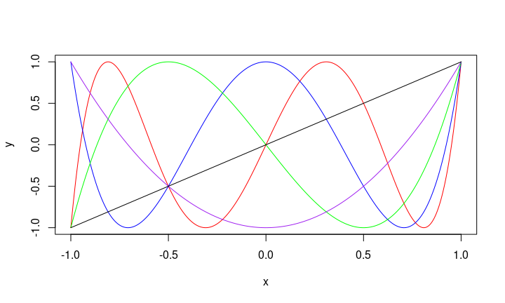

## Relación con la aproximación minimax

Veamos cuál es la relación de los **polinomios de Chebyschev** con la **aproximación minimax**. En primer lugar, necesitamos los resultados siguientes:

Proposición: ceros y extremos de los polinomios de Chebyschev.

El polinomio de Chebyschev \(T_n(x)\) de grado \(n\) tiene los \(n\) ceros siguientes en el intervalo \([-1,1]\): \[x_k = \cos\left(\frac{(2k+1)\pi}{2n}\right),\ \mbox{para }k=0,\ldots,n-1,\] y tiene los siguientes \(n+1\) extremos relativos en el intervalo \([-1,1]\): \[\hat{x}_k=\cos\left(\frac{k\pi}{n}\right),\ \mbox{para }k=0,1,\ldots,n,\] con valores extremos \(T_n(\hat{x}_k)=(-1)^k\).

## Demostración de la proposición

Usando que \(T_n(x)=\cos(n\arccos(x))\), podemos hallar los ceros de la forma siguiente: \[ \begin{align*} T_n(x)=& \cos(n\arccos(x))=0,\ \Rightarrow n\arccos(x)=\frac{\pi}{2}+k\pi =\frac{\pi +2k\pi}{2}=\frac{(2k+1)\pi}{2},\ \Rightarrow \\ \arccos(x) = & \frac{(2k+1)\pi}{2n},\ \Rightarrow x_k=\cos\left(\frac{(2k+1)\pi}{2n}\right),\ k\in\mathbb{Z}. \end{align*} \] Como \(\cos\left(\frac{(2k+1)\pi}{2n}\right)\in [-1,1]\), los ceros hallados están en el intervalo \([-1,1]\).

Los valores de \(k\) que dan ceros distintos son \(k=0,1,\ldots,n-1\) ya que para \(k=n\), obtenemos \[ x_n =\cos\left(\frac{(2n+1)\pi}{2n}\right)=\cos\left(\frac{\pi}{2n}+\pi\right)=\cos\left(-\frac{\pi}{2n}-\pi\right)=\cos\left(-\frac{\pi}{2n}+\pi\right)=\cos\left(\frac{(2n-1)\pi}{2n}\right)=x_{n-1}, \] volvemos a hallar \(x_{n-1}\) y se van repitiendo los ceros hallados. De hecho, la repetición sigue la pauta siguiente: \[ \begin{align*} x_{n+j}=& \cos\left(\frac{(2(n+j)+1)\pi}{2n}\right)=\cos\left(\frac{(2j+1)\pi}{2n}+\pi\right)=\cos\left(-\frac{(2j+1)\pi}{2n}-\pi\right)=\cos\left(-\frac{(2j+1)\pi}{2n}+\pi\right)\\ = & \cos\left(\frac{(2(n-j-1)+1)\pi}{2n}\right)=x_{n-j-1},\ j=0,1,\ldots \end{align*} \]

## Demostración de la proposición (continuación)

A continuación, hallemos los extremos del polinomio de Chebyschev \(T_n(x)\): \[ \begin{align*} T_n'(x)= & -\sin(n\arccos(x))\cdot n\cdot (\arccos(x))' =-\sin(n\arccos(x))\cdot n\cdot\left(-\frac{1}{\sqrt{1-x^2}}\right)=0,\ \Rightarrow\\ \sin(n\arccos(x))= & 0,\ \Rightarrow n\arccos(x)=k\pi,\ \Rightarrow \arccos(x) = \frac{k\pi}{n},\ \Rightarrow x_k =\cos\left(\frac{k\pi}{n}\right),\ k\in\mathbb{Z}. \end{align*} \] Como \(\cos\left(\frac{k\pi}{n}\right)\in [-1,1]\), los extremos hallados están en el intervalo \([-1,1]\).

Los valores de \(k\) que dan extremos distintos son \(k=0,1,\ldots,n\) ya que para \(k=n+1\), obtenemos: \[ x_{n+1} = \cos\left(\frac{(n+1)\pi}{n}\right)=\cos\left(\frac{\pi}{n}+\pi\right)=\cos\left(-\frac{\pi}{n}-\pi\right)=\cos\left(-\frac{\pi}{n}+\pi\right)=\cos\left(\frac{(n-1)\pi}{n}\right)=x_{n-1}, \] volvemos a hallar \(x_{n-1}\) y se van repitiendo los extremos hallados. De hecho, la repetición sigue la pauta siguiente: \[ x_{n+j} = \cos\left(\frac{(n+j)\pi}{n}\right)=\cos\left(\frac{j\pi}{n}+\pi\right)=\cos\left(-\frac{j\pi}{n}-\pi\right)=\cos\left(-\frac{j\pi}{n}+\pi\right)=\cos\left(\frac{(n-j)\pi}{n}\right)=x_{n-j}, \] donde \(j=1,2,\ldots\)

## Observación sobre el Teorema

En el Teorema anterior se dice que el **polinomio de Chebyschev** de grado \(n\), \(T_n(x)\) tiene \(n+1\) extremos, \(\hat{x}_k=\cos\left(\frac{k\pi}{n}\right)\), \(k=0,\ldots,n\).

Ahora bien, si \(T_n(x)\) es un polinomio de grado \(n\), sólo puede tener \(n-1\) extremos relativos como máximo que serían los que anulan la derivada que sería un polinomio de grado \(n-1\), pero en el Teorema hemos hallado \(n+1\)!

¿Cómo es posible?

De hecho, extremos que anulen la derivada sólo hay \(n-1\): \(\hat{x}_1,\ldots,\hat{x}_{n-1}\).

Los valores \(\hat{x}_0=1\), \(\hat{x}_n=-1\) son extremos en el intervalo \([-1,1]\) en el sentido de que \(|T_n(\hat{x}_0)|=|T_n(1)|=|T_n(\hat{x}_n)|=|T_n(-1)|=1\) alcanzan el valor máximo de \(|T_n(x)|\) en el intervalo \([-1,1]\) pero no anulan la derivada \(T_n'(x)\).

Veámoslo. Recordemos que \(T_n'(x)\) vale: \[ T_n'(x)=\sin(n\arccos(x))\cdot n\cdot\left(\frac{1}{\sqrt{1-x^2}}\right). \]

## Observación sobre el Teorema (continuación)

Si intentamos calcular \(T_n'(\hat{x}_0)=T_n'(1)\), obtenemos: \[ T_n'(1)=\sin(n\arccos(1))\cdot n\cdot \left(\frac{1}{\sqrt{1-1^2}}\right)=\frac{n\cdot \sin(n\cdot 0)}{\sqrt{1-1^2}}=\frac{n\cdot\sin(0)}{\sqrt{1-1^2}}=\frac{n\cdot 0}{0}=\frac{0}{0}. \] Nos queda una indeterminación del tipo \(\frac{0}{0}\). Por tanto, para calcular \(T_n'(1)\) tendremos que realizar el límite \(\displaystyle T_n'(1)=\lim_{x\to 1}T_n'(x)\).

El valor de \(T_n'(\hat{x}_0)\) será, por tanto, \[ T_n'(\hat{x_0})= T_n'(1)=\lim_{x\to 1}\sin(n\arccos(x))\cdot n\cdot\left(\frac{1}{\sqrt{1-x^2}}\right)=n\lim_{x\to 1}\frac{\sin(n\arccos(x))}{\sqrt{1-x^2}}. \] Para realizar el límite anterior, hacemos el cambio \(x=\cos(\theta)\), o \(\theta=\arccos(x)\). Como \(x\to 1\), \(\theta\to\arccos(1)=0\) y \(\sqrt{1-x^2}=\sqrt{1-\cos^2(\theta)}=\sin(\theta)\), \[ T_n'(\hat{x_0})=n\lim_{\theta\to 0}\frac{\sin(n\theta)}{\sin(\theta)}=n\lim_{\theta\to 0}\frac{n\cos(n\theta)}{\cos(\theta)}=n\cdot n=n^2. \]

## Observación sobre el Teorema (continuación)

Si intentamos calcular \(T_n'(\hat{x}_n)=T_n'(-1)\), obtenemos: \[ T_n'(-1)=\sin(n\arccos(-1))\cdot n\cdot \left(\frac{1}{\sqrt{1-1^2}}\right)=\frac{n\cdot \sin(n\cdot \pi)}{\sqrt{1-1^2}}=\frac{n\cdot 0}{0}=\frac{0}{0}. \] Nos queda una indeterminación del tipo \(\frac{0}{0}\). Por tanto, para calcular \(T_n'(-1)\) tendremos que realizar el límite \(\displaystyle T_n'(-1)=\lim_{x\to -1}T_n'(x)\).

El valor de \(T_n'(\hat{x}_n)\) será, por tanto, \[ \begin{align*} T_n'(\hat{x_n})= & T_n'(-1)=\lim_{x\to -1}\sin(n\arccos(x))\cdot n\cdot\left(\frac{1}{\sqrt{1-x^2}}\right)=n\lim_{x\to -1}\frac{\sin(n\arccos(x))}{\sqrt{1-x^2}}\\ = & n\lim_{\theta\to \pi}\frac{\sin(n\theta)}{\sin(\theta)}=n\lim_{\theta\to \pi}\frac{n\cos(n\theta)}{\cos(\theta)}=n\cdot\frac{n\cos(n\pi)}{\cos(\pi)}=n\cdot\frac{n\cdot (-1)^n}{-1}=n^2\cdot (-1)^{n-1}=(-1)^{n+1}\cdot n^2, \end{align*} \] donde hemos realizado el cambio anterior \(x=\cos(\theta)\), \(\theta =\arccos(x)\). Como \(x\to -1\), \(\theta\to\arccos(-1)=\pi\).

## Coeficiente del término de mayor grado

Proposición. Coeficiente del término de mayor grado del polinomio de Chebyschev.

El coeficiente del término de \(x^n\) del polinomio de Chebyschev de grado \(n\), \(T_n(x)\) vale \(2^{n-1}\) para \(n\geq 1\).

**Demostración**

Hagamos la demostración por inducción.

Como \(T_1(x)=x\), la proposición se cumple para \(n=1\): \(2^{1-1}=1\).

Supongamos ahora que el coeficiente del término de \(x^k\) de \(T_k(x)\) vale \(2^{k-1}\) para \(k=1,\ldots,n-1\).

Usando la recurrencia vista anteriormente \(T_{n}(x)=2xT_{n-1}(x)-T_{n-2}(x),\) tendremos que el coeficiente del término de \(x^n\) de \(T_n(x)\) será \(2\cdot\mathrm{coeficiente\ de\ }x^{n-1}\) de \(T_{n-1}\).

Ahora bien, por hipótesis de inducción, el coeficiente de \(x^{n-1}\) de \(T_{n-1}\) vale \(2^{n-2}\). Por tanto, el coeficiente del término de \(x^n\) de \(T_n(x)\) será \(2\cdot 2^{n-2}=2^{n-1}\), tal como queríamos demostrar.

## Polinomios mónicos de Chebyschev

Definimos los **polinomios mónicos de Chebyschev** \(\tilde{T}_n\) como los **polinomios de Chebyschev** divididos por su término principal de \(x^n\), \(2^{n-1}\):

Definición de los polinomios mónicos de Chebyschev.

El **polinomio mónimo de Chebyschev** \(\tilde{T}_n\) se define como: \(\tilde{T}_n=\frac{T_n(x)}{2^{n-1}}\).

Se llaman **mónicos** porque el coeficiente principal del **polinomio mónico de Chebyschev** de grado \(n\), \(\tilde{T}_n\) vale \(1\).

De esta forma podemos escribir: \(\tilde{T}_n(x) = x^n+\cdots\)

## Polinomios mónicos de Chebyschev

Usando que los **polinomios de Chebyschev** verifican la recurrencia \(T_{n}(x)=2xT_{n-1}(x)-T_{n-2}(x),\) podemos deducir la recurrencia que verifican los **polinomios mónicos de Chebyschev**: \[ \begin{align*} T_{n}(x)=& 2xT_{n-1}(x)-T_{n-2}(x),\ \Rightarrow \frac{T_n(x)}{2^{n-1}}=\frac{2xT_{n-1}(x)}{2^{n-1}}-\frac{T_{n-2}(x)}{2^{n-1}},\\ \frac{T_n(x)}{2^{n-1}}=&\frac{2x}{2}\cdot \frac{T_{n-1}(x)}{2^{n-2}}-\frac{1}{2^2}\cdot \frac{T_{n-2}(x)}{2^{n-3}},\ \Rightarrow \\ \tilde{T}_n = & x\cdot\tilde{T}_{n-1}-\frac{1}{4}\tilde{T}_{n-2}. \end{align*} \]

## Polinomios mónicos de Chebyschev

Los primeros **polinomios mónicos de Chebyschev** son los siguientes:

\[ \begin{align*} \tilde{T}_0(x) = & 1,\\ \tilde{T}_1(x) = & x,\\ \tilde{T}_2 (x)= & \frac{T_2(x)}{2} =\frac{2x^2-1}{2}=x^2-\frac{1}{2},\\ \tilde{T}_3 (x)= & x\tilde{T}_2(x) -\frac{1}{4}\tilde{T}_1(x) =x\left(x^2-\frac{1}{2}\right)-\frac{1}{4}x =x^3-\frac{3}{4}x,\\ \tilde{T}_4 (x)= & x\tilde{T}_3(x) -\frac{1}{4}\tilde{T}_2(x) =x\left(x^3-\frac{3}{4}x\right)-\frac{1}{4}\left(x^2-\frac{1}{2}\right)=x^4-x^2+\frac{1}{8}, \end{align*} \] y así sucesivamente.

## Polinomios mónicos de Chebyschev

Los primeros polinómicos mónicos de Chebyschev se muestran en la tabla siguiente:

| \(n\) | \(\tilde{T}_n\) |
| --- | --- |
| \(0\) | \(1\) |
| \(1\) | \(x\) |
| \(2\) | \(x^2-\frac{1}{2}\) |
| \(3\) | \(x^3-\frac{3x}{4}\) |
| \(4\) | \(x^4-x^2+\frac{1}{8}\) |
| \(5\) | \(x^5-\frac{5 x^3}{4}+\frac{5x}{16}\) |

## Relación con la norma infinito

El **polinomio mónico de Chebyschev** de grado \(n\), \(\tilde{T}_n\), minimiza la **norma infinito** en el intervalo \([-1,1]\) entre todos los **polinomios mónicos** de grado \(n\):

Teorema: minimización de la norma infinito.

Sea \(P_n(x)\) un polinomio **mónico** cualquiera de grado \(n\). Entonces, \[ \frac{1}{2^{n-1}}=\|\tilde{T}_n\|_\infty =\max_{x\in [-1,1]}|\tilde{T}_n(x)|\leq \|P_n\|_\infty =\max_{x\in [-1,1]}|P_n(x)|. \] Además la igualdad ocurre sólo si \(P_n\equiv\tilde{T}_n\).

## Demostración del Teorema

La condición \(\frac{1}{2^{n-1}}=\|\tilde{T}_n\|_\infty\) se deduce de las dos proposiciones anteriores.

Sabemos que \(T_n(x)\) y, por tanto, \(\tilde{T}_n(x) =\frac{1}{2^{n-1}}T_n(x)\) tiene \(n+1\) extremos relativos \(\hat{x}_k=\cos\left(\frac{k\pi}{n}\right)\), \(k=0,1,\ldots,n\) tal que \[ |T_n(\hat{x}_k)|=|(-1)^k|=1=\max_{x\in [-1,1]}|T_n(x)|=\|T_n\|_\infty. \] Por tanto, \[ \|\tilde{T}_n\|_\infty =\left\|\frac{1}{2^{n-1}}T_n\right\|_\infty =\frac{1}{2^{n-1}}\|T_n\|_\infty =\frac{1}{2^{n-1}}, \] tal como queríamos ver.

De cara a la demostración de que el polinomio mónico de Chebyschev de grado \(n\), \(\tilde{T}_n\), minimiza la norma infinito entre todos los polinómicos mónicos de grado menor o igual que \(n\), consideremos el problema siguiente de minimización minimax:

Sea \(f(x)=x^n\). Nos proponemos hallar el polinomio \(\hat{P}_{n-1}(x)\) de grado menor o igual que \(n-1\) que aproxima \(f(x)\) según la norma infinito en el intervalo \([-1,1]\). Es decir, queremos resolver el problema siguiente: \[ \|f-\hat{P}_{n-1}\|_\infty =\min_{P_{n-1}}\|f-P_{n-1}\|_\infty \]

## Demostración del Teorema (continuación)

Según el **Teorema de caracterización de aproximación minimax**, el polinomio \(\hat{P}_{n-1}\) debe cumplir lo siguiente:

si hallamos \(-1\leq\xi_0,\xi_1,\ldots,\xi_{n}\leq 1\), \(n-1+2=n+1\) valores numéricos en \([-1,1]\) tal que la función \(e_{n-1}(x)=f(x)-\hat{P}_{n+1}\) cumpla que: \[ |e_{n-1}(\xi_j)|=\|e_{n-1}\|_\infty =\max_{x\in [-1,1]}|e_{n-1}(x)|=\max_{x\in [-1,1]}|f(x)-\hat{P}_{n-1}(x)|, \] para \(j=0,1,\ldots,n\), con **alternancia de signos**: \[ e_{n-1}(\xi_0)=-e_{n-1}(\xi_1)=\cdots = (-1)^{n}e_{n-1}(\xi_{n}), \] tendremos resuelto nuestro problema.

El polinomio \(\hat{P}_{n-1}\) buscado vale \(\hat{P}_{n-1}(x)=x^n-\tilde{T}_n(x)\).

En primer lugar, observar que es un polinomio de grado menor o igual que \(n-1\) ya que el polinomio mónico de Chebyschev de grado \(n\) es de la forma \(\tilde{T}_n =x^n +\cdots\) y por tanto en la expresión \(x^n-\tilde{T}_n(x)\) sólo aparecerán términos de orden \(n-1\) como máximo.

En segundo lugar, la función \(e_{n-1}\) vale \(e_{n-1}(x)=x^n-(x^n-\tilde{T}_n)=\tilde{T}_n\) del que sabemos que existen \(\xi_i=\hat{x}_i=\cos\left(\frac{i\pi}{n}\right)\), \(i=0,1,\ldots,n\) cumpliendo las condiciones anteriores.

Queda, por tanto, resuelto el problema propuesto de aproximación minimax.

## Demostración del Teorema (continuación)

Veamos, para acabar la demostración, que el problema de aproximación minimax propuesto es equivalente a la tesis del Teorema.

Nuestro problema era hallar el mínimo de la norma infinito entre todos los polinomios mónicos de grado \(n\): \[ \min_{P_n\mbox{ mónico}}\|P_n\|_\infty. \] Ahora bien, cualquier polinomio mónico \(P_n\) de grado \(n\) puede escribirse como \(P_n(x)=x^n-P_{n-1}(x)\), donde \(P_{n-1}(x)\) es el polinomio de grado menor o igual que \(n-1\) siguiente: \(P_{n-1}(x)=x^n-P_n(x)\).

Nuestro problema puede reescribirse de la siguiente forma: hallar el polinomio de grado menor o igual que \(n-1\) que minimice: \[ \min_{P_{n-1}}\|x^n-P_{n-1}\|_\infty, \] que es precisamente el problema que hemos resuelto de aproximación minimax cuya solución hallada era: \(\hat{P}_{n-1}=x^n-\tilde{T}_n\). Por tanto: \[ \min_{P_n\mbox{ mónico}}\|P_n\|_\infty =\min_{P_{n-1}}\|x^n-P_{n-1}\|_\infty =\|x^n-(x^n-\tilde{T}_n)\|_\infty =\|\tilde{T}_n\|_\infty, \] tal como queríamos demostrar.

Además, la igualdad sólo ocurre si \(P_n=\tilde{T}_n\) por la unicidad de la solución del problema minimax.

## Relación con la norma infinito

En la demostración del Teorema anterior, hemos demostrado el corolario siguiente:

Corolario: aproximación minimax de la función \(x^n\) en el intervalo \([-1,1]\).

La **aproximación minimax** de la función \(f(x)=x^n\) en el intervalo \([-1,1]\) entre todos los polinomios de grado menor o igual que \(n-1\) es la función \(\hat{P}_{n-1}(x)=x^n-\tilde{T}_n(x)\), es decir: \[ \min_{P_{n-1}}\|x^n-P_{n-1}(x)\|_\infty =\|x^n-(x^n-\tilde{T}_n(x))\|_\infty. \]

## Ejemplo

Sea \(f(x)=x^3\). La aproximación minimax entre todos los polinomios de grado menor o igual que \(2\) de la función anterior es: \[ \hat{P}_2(x)=x^3-\tilde{T}_3(x)=x^3-\left(x^3-\frac{3x}{4}\right)=\frac{3}{4}x. \] Vemos que es una recta que pasa por el origen.

En la gráfica siguiente se muestra la función \(f(x)=x^3\) en negro y la aproximación \(\hat{P}_2(x)\) en rojo.

## Ejemplo (continuación)

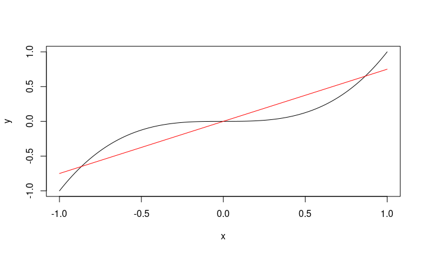

## Minimización del error de interpolación

En el tema dedicado a **interpolación** del curso **Métodos numéricos con Python. Cálculo Numérico** estudiamos cómo hallar el **polinomio de interpolación** de grado \(m\), \(P_m(x)\), dada una **nube de puntos** \((x_k,y_k),\ k=1,\ldots,m\), es decir, hallar un polinomio de grado menor o igual que \(m-1\) tal que \(P_m(x_k)=y_k\), \(k=1,\ldots,m\).

Además, en el caso en que la nube de puntos provenga de la gráfica de una función \(f(x)\), es decir \(y_k=f(x_k)\), donde dicha función \(f\in {\cal C}^{m+1}\) es de clase \(m+1\), el **error de interpolación** se puede escribir de la forma siguiente: \[ f(x)-P_m(x)=\frac{f^{(m+1)}(\xi(x))}{(m+1)!}(x-x_0)(x-x_1)\cdots (x-x_m). \]

## Minimización del error de interpolación

Notemos que el error depende del **polinomio mónico** \((x-x_0)(x-x_1)\cdots (x-x_m)\) de grado \(m+1\).

Si suponemos que los **nodos de interpolación** están en el intervalo \([-1,1]\), nos podríamos plantear cómo elegir los nodos \(x_k,\ k=0,1,\ldots,m\) en dicho intervalo de tal forma que el **máximo del polinomio anterior** \(|(x-x_0)(x-x_1)\cdots (x-x_m)|\) sea **mínimo**. Es decir, nos planteamos el problema siguiente: \[ \begin{align*} & \min_{x_0,x_1,\ldots,x_m}\max_{x\in [-1,1]}|(x-x_0)(x-x_1)\cdots (x-x_m)|\\ & \quad = \min_{x_0,x_1,\ldots,x_m}\|(x-x_0)(x-x_1)\cdots (x-x_m)\|_\infty. \end{align*} \] El problema anterior es equivalente a hallar el **polinomio mónico de grado \(m+1\)** que minimice la **norma infinito** en el intervalo \([-1,1]\).

## Minimización del error de interpolación

Dicho problema ya está resuelto eligiendo el **polinomio mónico de Chebyschev** de grado \(m+1\), \(\tilde{T}_{m+1}\).

Por tanto, los nodos \(x_k,\ k=0,1,\ldots,m+1\) se tienen que elegir de tal forma que se cumpla: \[ \tilde{T}_{m+1}(x)=(x-x_0)(x-x_1)\cdots (x-x_m), \] es decir, los nodos \(x_k,\ k=0,1,\ldots,m\) deben ser los **ceros** del **polinomio de Chebyschev** \(T_{m+1}(x)\): \[ x_k = \cos\left(\frac{(2k+1)\pi}{2(m+1)}\right),\ k=0,1,\ldots,m. \]

## Minimización del error de interpolación

Hemos demostrado el corolario siguiente:

Corolario.

Sea \(f\in {\cal C}^{m+1}\) una función de clase \(m+1\) y sea \(P_m(x)\) el **polinomio de interpolación** en los ceros \(x_k=\cos\left(\frac{(2k+1)\pi}{2(m+1)}\right),\ k=0,1,\ldots,m\) del **polinomio de Chebyschev** de grado \(m+1\). Entonces, \[ \max_{x\in [-1,1]}|(x-x_0)(x-x_1)\ldots (x-x_m)|=\|\tilde{T}_{m+1}\|_\infty = \frac{1}{2^m}. \]

## Minimización del error de interpolación

Corolario. (continuación)

Además el error de interpolación \(f(x)-P_m(x)\) en cualquier \(x\in [-1,1]\) se puede acotar por: \[ \begin{align*} \max_{x\in [-1,1]}|f(x)-P_m(x)|= & \max_{x\in [-1,1]}\left|\frac{f^{(m+1)}(\xi(x))}{(m+1)!}(x-x_0)(x-x_1)\cdots (x-x_m)\right|\\\leq &\frac{1}{2^m\cdot (m+1)!}\max_{x\in [-1,1]}\left|f^{(m+1)}(\xi(x))\right|\leq \frac{\|f^{(m+1)}\|_\infty}{2^m\cdot (m+1)!} \end{align*} \]

Observación.

El **fenómeno de Runge** que vimos en el curso **Métodos Numéricos con Python. Cálculo Numérico** que ocurría cuando interpolamos la función \(f(x)=\frac{1}{1+5x^2}\) en el intervalo \([-1,1]\) **desaparece** cuando consideramos como **nodos de interpolación** los **ceros del polinomio de Chebyschev** correspondiente.

## Generalización a un intervalo cualquiera \([a,b]\)

Supongamos que tenemos una función \(f\in {\cal C}^{m+1}\) de clase \(m+1\) en un intervalo cualquiera \([a,b]\) y consideramos \(t_0,t_1,\ldots,t_m\), \(m+1\) puntos en dicho intervalo.

Sea \(P_m(t)\) el **polinomio de interpolación** de grado menor o igual que \(m\) en los puntos anteriores, es decir \(P_m(t_k)=f(t_k),\ k=0,1,\ldots,m\)

Sabemos que el **error de interpolación** (ver tema de interpolación del curso **Métodos numéricos con Python. Cálculo Numérico**) tiene la expresión siguiente: \[ f(t)-P_m(t)=\frac{f^{m+1}(\xi(t))}{(m+1)!}(t-t_0)(t-t_1)\cdots (t-t_m). \]

## Generalización a un intervalo cualquiera \([a,b]\)

A continuación, nos planteamos la misma cuestión que hacíamos en el intervalo \([-1,1]\): ¿existe alguna manera de elegir los nodos \(t_k,\ k=0,1,\ldots,m\) que **minimice** la **norma infinito** de la parte del **error de interpolación** que depende de dichos nodos, \(\|(t-t_0)(t-t_1)\cdots (t-t_m)\|_\infty =\max_{t\in [a,b]}|(t-t_0)(t-t_1)\cdots (t-t_m)|\)?

Para responder a dicha pregunta, basta considerar los **ceros del polinomio de Chebyschev** de grado \(m\), \(T_m(x)\) pero considerados en el intervalo \([a,b]\).

Es decir, hay que considerar la siguiente aplicación que pasa del intervalo \([-1,1]\) al intervalo \([a,b]\), \(t=\frac{1}{2}((b-a)x+a+b)\) y transformar los **ceros del polinomio de Chebyschev** de grado \(m\) usando dicha transformación.

## Generalización a un intervalo cualquiera \([a,b]\)

Como los **ceros del polinomio de Chebyschev** de grado \(m\) en el intervalo \([-1,1]\) son \(x_k=\cos\left(\frac{(2k+1)\pi}{2(m+1)}\right)\), los nodos que **minimizan la norma infinito** de la parte del error de interpolación que depende de dichos nodos serán: \[ t_k =\frac{1}{2}((b-a)x_k+a+b)=\frac{1}{2}\left((b-a)\cos\left(\frac{(2k+1)\pi}{2(m+1)}\right)+a+b\right), \] para \(k=0,1,\ldots,m\).

## Generalización a un intervalo cualquiera \([a,b]\)

El valor de la norma infinito \(\|(t-t_0)(t-t_1)\cdots (t-t_m)\|_\infty\) en los nodos anteriores será: \[ \begin{align*} & \|(t-t_0)(t-t_1)\cdots (t-t_m)\|_\infty =\max_{t\in [a,b]}|(t-t_0)(t-t_1)\cdots (t-t_m)|\\ & \quad =\max_{t\in [a,b]}\prod_{k=0}^m |t-t_k|=\max_{x\in [-1,1]}\prod_{k=0}^m \left|\frac{1}{2}((b-a)x+a+b)-\frac{1}{2}((b-a)x_k+a+b)\right|\\ & \quad = \left(\frac{b-a}{2}\right)^{m+1}\max_{x\in [-1,1]}\prod_{k=0}^m |x-x_k|=\left(\frac{b-a}{2}\right)^{m+1}\|\tilde{T}_{m+1}\|_\infty \\ & \quad =\left(\frac{b-a}{2}\right)^{m+1}\cdot\frac{1}{2^{m}}=\frac{(b-a)^{m+1}}{2^{2m+1}}. \end{align*} \]

## Ejemplo

Consideremos la función \(f(x)=\sin(x^2)\) definida en el intervalo \([0,\pi]\).

Vamos a hallar el polinomio de interpolación de grado \(m=3\) en los nodos que minimizan la norma infinito de la parte del error de interpolación que depende de dichos nodos.

En nuestro caso \(a=0\) y \(b=\pi\). Los nodos a considerar serán: \[ \begin{align*} t_k =& \frac{1}{2}\left((\pi-0)\cos\left(\frac{(2k+1)\pi}{2\cdot (3+1)}\right)+0+\pi\right)=\frac{1}{2}\left(\pi\cos\left(\frac{(2k+1)\pi}{8}\right)+\pi\right)\\= &3.0220229, 2.1719141, 0.9696786, 0.1195698 \end{align*} \] A continuación hallamos el polinomio de interpolación usando el enlace del curso **Métodos numéricos con Python. Cálculo Numérico**:

El polinomio interpolador es el siguiente: \[ \begin{align*} P_3(x)= & 0.93332141411505\cdot x+(0.141976674265924-1.18739576603727\cdot x)(x−0.9696786)\\ & \quad +(0.915868383580237\cdot x-0.109510199451012)(x-2.1719141)(x-0.9696786)\\ & \quad -0.0973006047991673. \end{align*} \]

## Ejemplo (continuación)

La gráfica siguiente muestra la función \(f(x)=\sin(x^2)\) en negro junto con el polinomio interpolador en rojo:

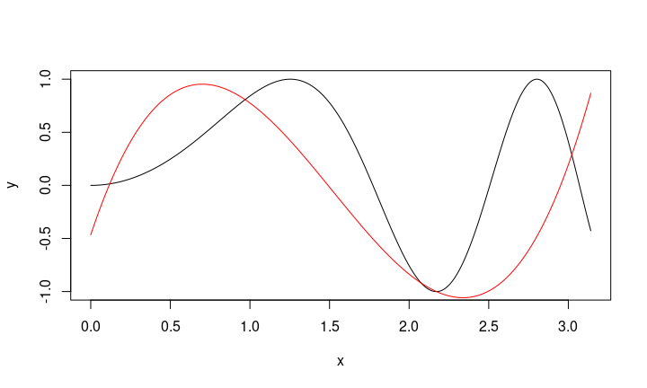

## Ejemplo (continuación)

El valor de \(\|(t-t_0)(t-t_1)(t-t_2)(t-t_3)\|_\infty\) vale en este caso: \[ \|(t-t_0)(t-t_1)(t-t_2)(t-t_3)\|_\infty =\max_{t\in [0,\pi]}|(t-t_0)(t-t_1)(t-t_2)(t-t_3)|=\frac{(\pi-0)^{3+1}}{2^{2\cdot 3+1}}=\frac{\pi^4}{2^7}=0.7610085. \] El error de interpolación en cualquier valor \(t\) del intervalo \([0,\pi]\) se puede acotar por: \[ \begin{align*} |f(t)-P_3(t)|= & \left|\frac{f^{(4)}(\xi(t))}{4!}(t-t_0)(t-t_1)(t-t_2)(t-t_3)\right|\leq \frac{1}{24}\|f^{(4)}\|_\infty\cdot \frac{\pi^4}{2^7}=\frac{\pi^4}{3072}\|f^{(4)}\|_\infty \\ = & 0.0317087\cdot \|f^{(4)}\|_\infty. \end{align*} \]